# Time dependent Cox

```r
ggcoxzph(resm5)[2]
```

```
## $`2`
```

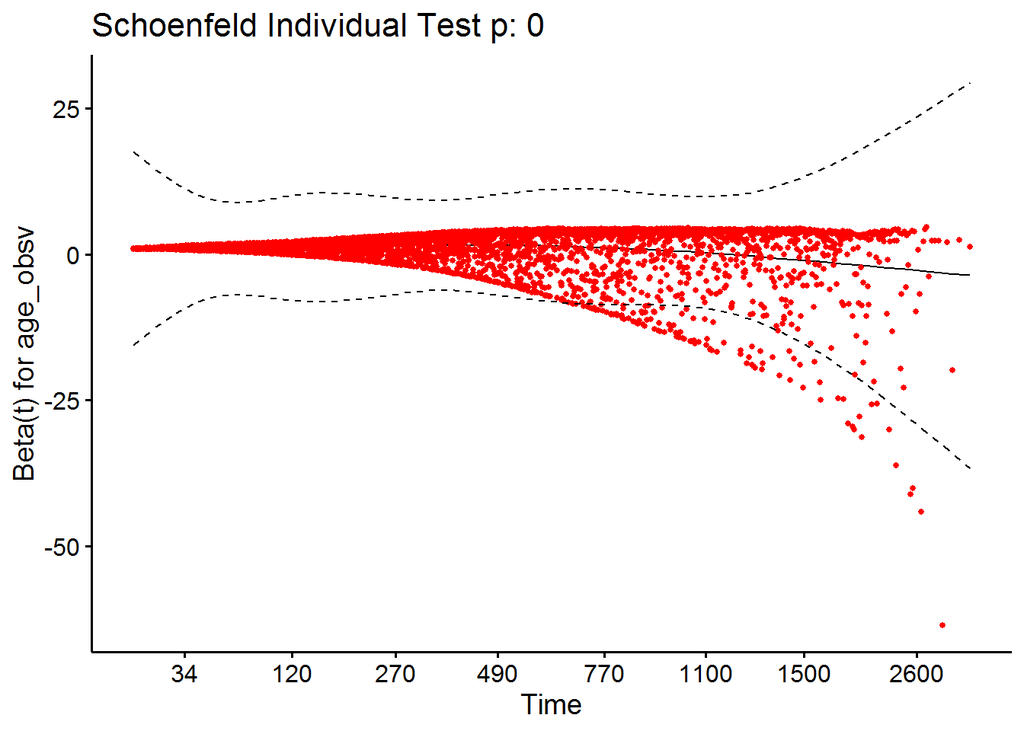

```r
ggcoxzph(resm5)[3]
```

```
## $`3`
```

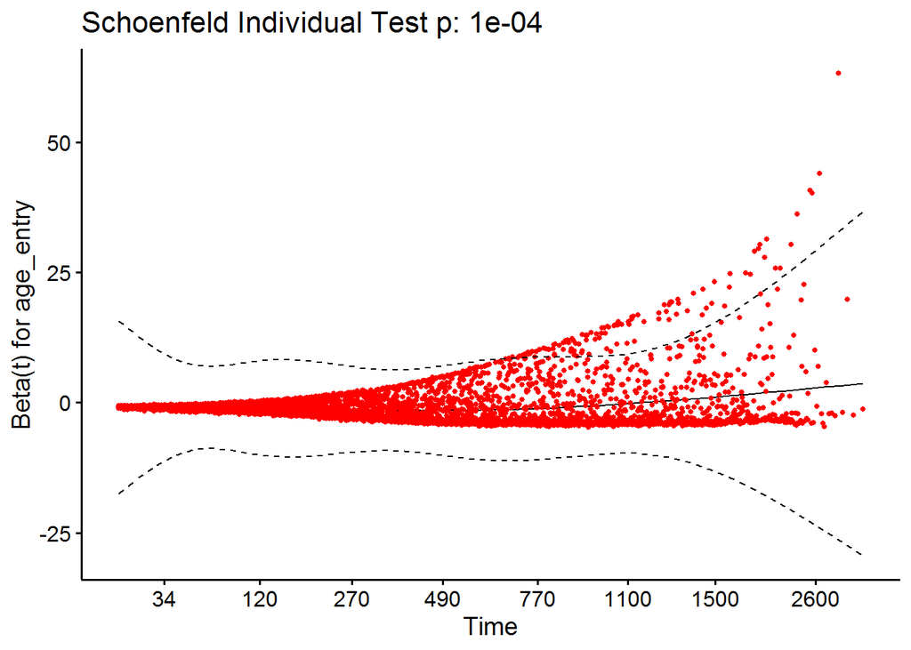

```r
anova(cox_m5)
```

```
## Analysis of Deviance Table
##  Cox model: response is Surv(time1, time2, event_death)
## Terms added sequentially (first to last)
##
##              loglik     Chisq Df Pr(>|Chi|)
## NULL         -42295
## Gender_Value -42294    2.7536  1    0.09703 .
## age_obsv     -41476 1635.5929  1    < 2e-16 ***
## age_entry    -41056  841.0375  1    < 2e-16 ***
## ---
## Signif. codes:  0 '***' 0.001 '**' 0.01 '*' 0.05 '.' 0.1 ' ' 1
```

**Gender, age at observation, and age of diagnosis**

```r
cox_m6 <- coxph(Surv(time1, time2, event_death) ~ Gender_Value + age_obsv + age_diag, data = all_df)

summary(cox_m6)
```

```
## Call:
## coxph(formula = Surv(time1, time2, event_death) ~ Gender_Value +
##     age_obsv + age_diag, data = all_df)
##
##   n= 58973, number of events= 5145
##
##                      coef exp(coef) se(coef)       z Pr(>|z|)
## Gender_ValueMale  0.18050   1.19782  0.02880   6.267 3.68e-10 ***
## age_obsv          0.36702   1.44343  0.01301  28.214  < 2e-16 ***
## age_diag         -0.28565   0.75153  0.01276 -22.390  < 2e-16 ***
## ---
## Signif. codes:  0 '***' 0.001 '**' 0.01 '*' 0.05 '.' 0.1 ' ' 1
##
##                  exp(coef) exp(-coef) lower .95 upper .95
## Gender_ValueMale    1.1978     0.8349     1.132    1.2674
## age_obsv            1.4434     0.6928     1.407    1.4807
## age_diag            0.7515     1.3306     0.733    0.7706
##
## Concordance= 0.675  (se = 0.004 )
## Likelihood ratio test= 2135  on 3 df,   p=<2e-16
## Wald test            = 1897  on 3 df,   p=<2e-16
## Score (logrank) test = 1878  on 3 df,   p=<2e-16
```

```r
cox.zph(cox_m6)
```

```
##              chisq df     p
## Gender_Value 0.899  1 0.343
## age_obsv     5.915  1 0.015
## age_diag     6.252  1 0.012
## GLOBAL       8.184  3 0.042
```

```r
resm6 <- cox.zph(cox_m6)

ggcoxzph(resm6)[1]
```

```
## $`1`
```

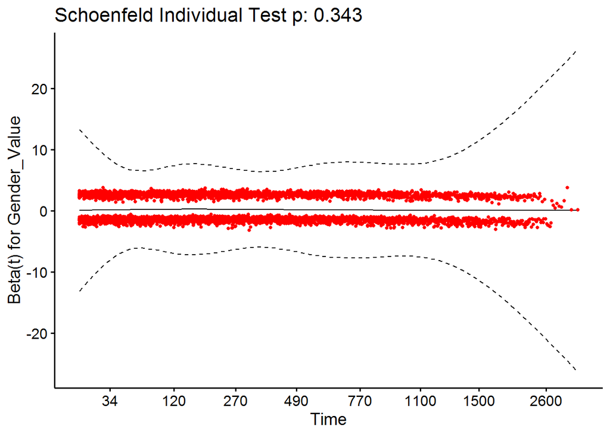

```r
ggcoxzph(resm6)[2]
```

```
## $`2`
```

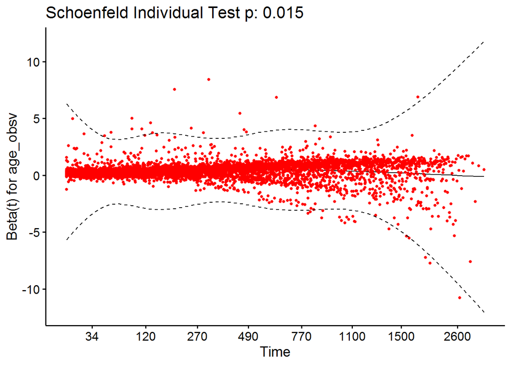

```r
ggcoxzph(resm6)[3]
```

```
## $`3`
```

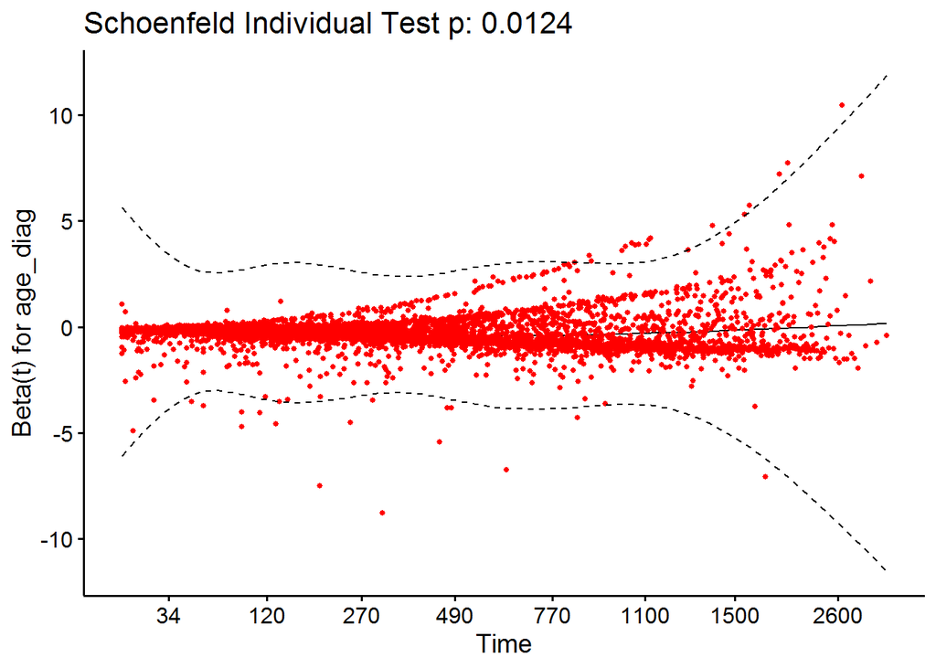

```r
anova(cox_m6)
```

```
## Analysis of Deviance Table
##  Cox model: response is Surv(time1, time2, event_death)
## Terms added sequentially (first to last)
##
##              loglik     Chisq Df Pr(>|Chi|)
## NULL         -42295
## Gender_Value -42294    2.7536  1    0.09703 .
## age_obsv     -41476 1635.5929  1    < 2e-16 ***
## age_diag     -41228  496.3652  1    < 2e-16 ***
## ---
## Signif. codes:  0 '***' 0.001 '**' 0.01 '*' 0.05 '.' 0.1 ' ' 1
```

**Gender, age at observation, and dementia medication exposure**

```r
cox_m7 <- coxph(Surv(time1, time2, event_death) ~ Gender_Value + age_obsv + med_exposure, data = all_df)

summary(cox_m7)
```

```
## Call:
## coxph(formula = Surv(time1, time2, event_death) ~ Gender_Value +
##     age_obsv + med_exposure, data = all_df)
##
##   n= 58973, number of events= 5145
##
##                          coef exp(coef) se(coef)      z Pr(>|z|)
## Gender_ValueMale      0.21740   1.24284  0.02875  7.562 3.96e-14 ***
## age_obsv              0.08328   1.08685  0.00213 39.103  < 2e-16 ***
## med_exposureunexposed 0.22673   1.25449  0.02933  7.730 1.08e-14 ***
## ---
## Signif. codes:  0 '***' 0.001 '**' 0.01 '*' 0.05 '.' 0.1 ' ' 1
##
##                       exp(coef) exp(-coef) lower .95 upper .95
## Gender_ValueMale          1.243     0.8046     1.175     1.315
## age_obsv                  1.087     0.9201     1.082     1.091
## med_exposureunexposed     1.254     0.7971     1.184     1.329
##
## Concordance= 0.668  (se = 0.004 )
## Likelihood ratio test= 1697  on 3 df,   p=<2e-16
## Wald test            = 1546  on 3 df,   p=<2e-16
## Score (logrank) test = 1562  on 3 df,   p=<2e-16
```

```r
cox.zph(cox_m7)
```

```
##                chisq df      p
## Gender_Value   0.136  1   0.71
## age_obsv       1.606  1   0.21
## med_exposure 142.256  1 <2e-16
## GLOBAL       149.251  3 <2e-16
```

```r
resm7 <- cox.zph(cox_m7)

ggcoxzph(resm7)[1]
```

```
## $`1`
```

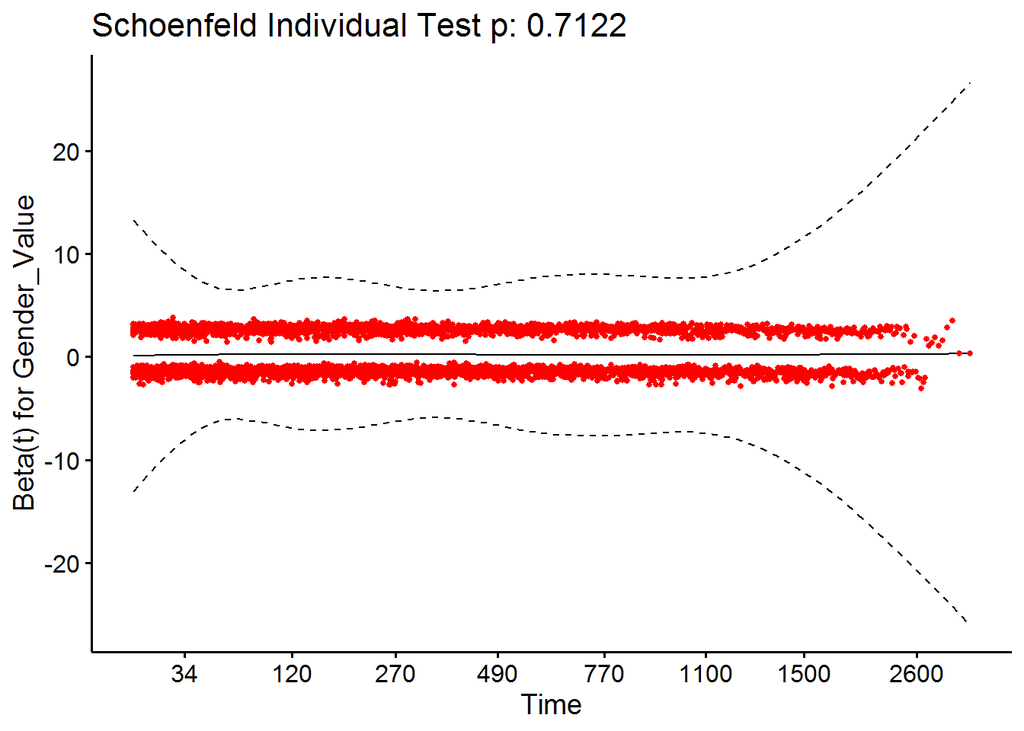

```r
ggcoxzph(resm7)[2]
```

```
## $`2`
```

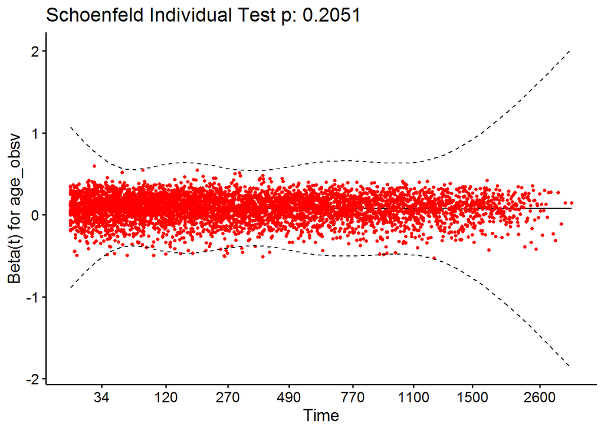

```r
ggcoxzph(resm7)[3]
```

```
## $`3`
```

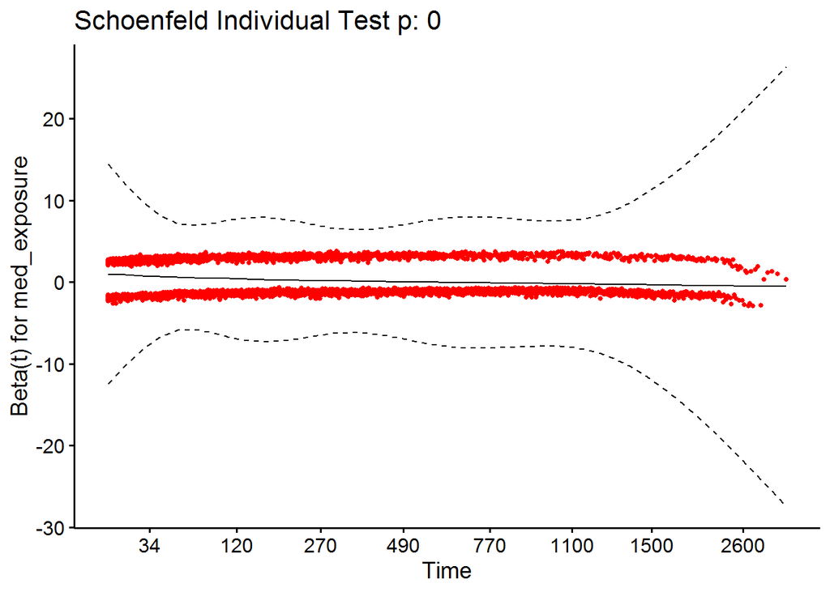

```r
anova(cox_m7)
```

```
## Analysis of Deviance Table
##  Cox model: response is Surv(time1, time2, event_death)
## Terms added sequentially (first to last)
##
##              loglik     Chisq Df Pr(>|Chi|)
## NULL         -42295
## Gender_Value -42294    2.7536  1    0.09703 .
## age_obsv     -41476 1635.5929  1  < 2.2e-16 ***
## med_exposure -41447   58.4610  1  2.074e-14 ***
## ---
## Signif. codes:  0 '***' 0.001 '**' 0.01 '*' 0.05 '.' 0.1 ' ' 1
```

**Gender, age at observation, and initial diagnosis**

```r
cox_m8 <- coxph(Surv(time1, time2, event_death) ~ Gender_Value + age_obsv + cause_diagper,
                data = all_df)

summary(cox_m8)
```

```
## Call:
## coxph(formula = Surv(time1, time2, event_death) ~ Gender_Value +
##     age_obsv + cause_diagper, data = all_df)
##
##   n= 58973, number of events= 5145
##
##                              coef exp(coef) se(coef)      z Pr(>|z|)
## Gender_ValueMale         0.209560  1.233135 0.028775  7.283 3.27e-13 ***
## age_obsv                 0.081609  1.085031 0.002139 38.152  < 2e-16 ***
## cause_diagperDLB         0.258291  1.294715 0.095457  2.706  0.00681 **
## cause_diagperFTD         0.023245  1.023518 0.220002  0.106  0.91585
## cause_diagperMixedADVaD  0.095313  1.100003 0.138432  0.689  0.49113
## cause_diagperPPD         0.643412  1.902963 0.289879  2.220  0.02645 *
## cause_diagperUnspecified 0.137667  1.147594 0.030948  4.448 8.66e-06 ***
## cause_diagperVaD         0.385548  1.470420 0.060618  6.360 2.01e-10 ***
## ---
## Signif. codes:  0 '***' 0.001 '**' 0.01 '*' 0.05 '.' 0.1 ' ' 1
##
##                          exp(coef) exp(-coef) lower .95 upper .95
## Gender_ValueMale             1.233     0.8109    1.1655     1.305
## age_obsv                     1.085     0.9216    1.0805     1.090
## cause_diagperDLB             1.295     0.7724    1.0738     1.561
## cause_diagperFTD             1.024     0.9770    0.6650     1.575
## cause_diagperMixedADVaD      1.100     0.9091    0.8386     1.443
## cause_diagperPPD             1.903     0.5255    1.0782     3.359
## cause_diagperUnspecified     1.148     0.8714    1.0801     1.219
## cause_diagperVaD             1.470     0.6801    1.3057     1.656
##
## Concordance= 0.664  (se = 0.004 )
## Likelihood ratio test= 1689  on 8 df,   p=<2e-16
## Wald test            = 1518  on 8 df,   p=<2e-16
## Score (logrank) test = 1533  on 8 df,   p=<2e-16
```

```r
cox.zph(cox_m8)
```

```
##                chisq df       p
## Gender_Value   0.107  1 0.74375
## age_obsv       2.445  1 0.11794
## cause_diagper 24.119  6 0.00050
## GLOBAL        26.665  8 0.00081
```

```r
resm8 <- cox.zph(cox_m8)

ggcoxzph(resm8)[1]
```

```
## $`1`
```

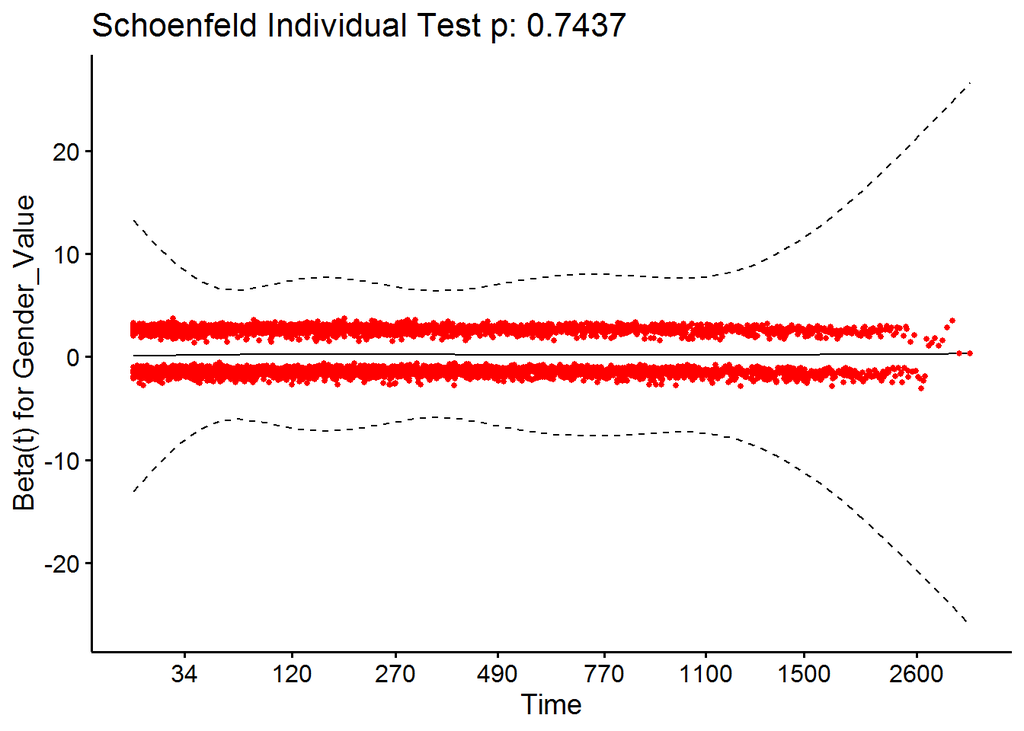

```r
ggcoxzph(resm8)[2]
```

```
## $`2`
```

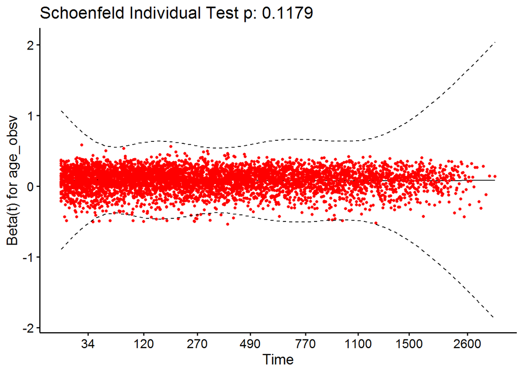

```r
ggcoxzph(resm8)[3]
```

```
## $`3`
```

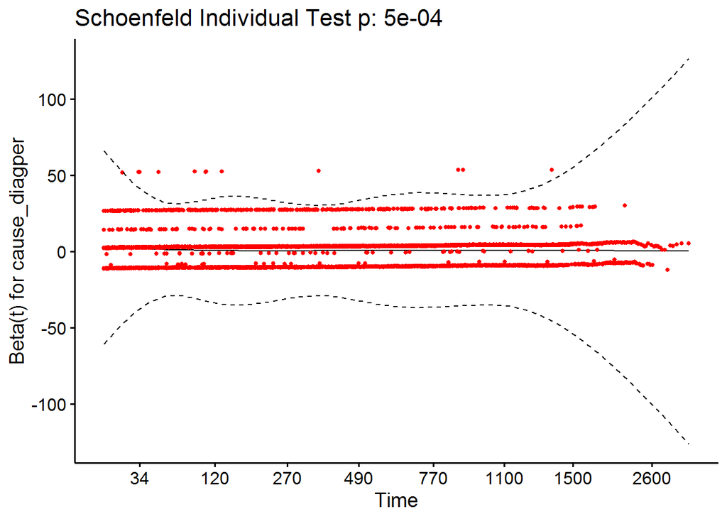

```r
anova(cox_m8)
```

```
## Analysis of Deviance Table
##  Cox model: response is Surv(time1, time2, event_death)
## Terms added sequentially (first to last)
##
##               loglik     Chisq Df Pr(>|Chi|)
## NULL          -42295
## Gender_Value  -42294    2.7536  1    0.09703 .
## age_obsv      -41476 1635.5929  1  < 2.2e-16 ***
## cause_diagper -41451   50.6106  6  3.546e-09 ***
## ---
## Signif. codes:  0 '***' 0.001 '**' 0.01 '*' 0.05 '.' 0.1 ' ' 1
```

**Gender, age at observation, and racial group**

```r
cox_m9 <- coxph(Surv(time1, time2, event_death) ~ Gender_Value + age_obsv + Ethnicity_Value, data = all_df)

summary(cox_m9)
```

```
## Call:
## coxph(formula = Surv(time1, time2, event_death) ~ Gender_Value +
##     age_obsv + Ethnicity_Value, data = all_df)
##
##   n= 42829, number of events= 3626
##    (16144 observations deleted due to missingness)
##
##                           coef exp(coef)  se(coef)      z Pr(>|z|)
## Gender_ValueMale      0.184580  1.202714  0.034468  5.355 8.55e-08 ***
## age_obsv              0.079937  1.083219  0.002527 31.628  < 2e-16 ***
## Ethnicity_ValueOther -0.016982  0.983161  0.175198 -0.097    0.923
## Ethnicity_ValueAsian -0.270102  0.763302  0.209690 -1.288    0.198
## Ethnicity_ValueBlack  0.236058  1.266247  0.224370  1.052    0.293
## ---
## Signif. codes:  0 '***' 0.001 '**' 0.01 '*' 0.05 '.' 0.1 ' ' 1
##
##                      exp(coef) exp(-coef) lower .95 upper .95
## Gender_ValueMale        1.2027     0.8315    1.1241     1.287
## age_obsv                1.0832     0.9232    1.0779     1.089
## Ethnicity_ValueOther    0.9832     1.0171    0.6974     1.386
## Ethnicity_ValueAsian    0.7633     1.3101    0.5061     1.151
## Ethnicity_ValueBlack    1.2662     0.7897    0.8157     1.966
##
## Concordance= 0.66  (se = 0.005 )
## Likelihood ratio test= 1131  on 5 df,   p=<2e-16
## Wald test            = 1011  on 5 df,   p=<2e-16
## Score (logrank) test = 1025  on 5 df,   p=<2e-16
```

```r
cox.zph(cox_m9)
```

```
##                   chisq df     p
## Gender_Value     0.0307  1 0.861
## age_obsv         2.8240  1 0.093
## Ethnicity_Value  8.4215  3 0.038
## GLOBAL          11.1660  5 0.048
```

```r
resm9 <- cox.zph(cox_m9)

ggcoxzph(resm9)[1]
```

```
## $`1`
```

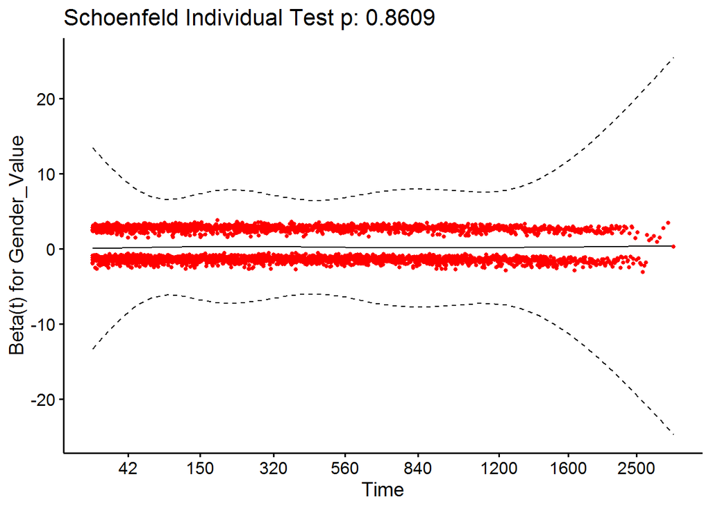

```r
ggcoxzph(resm9)[2]
```

```
## $`2`
```

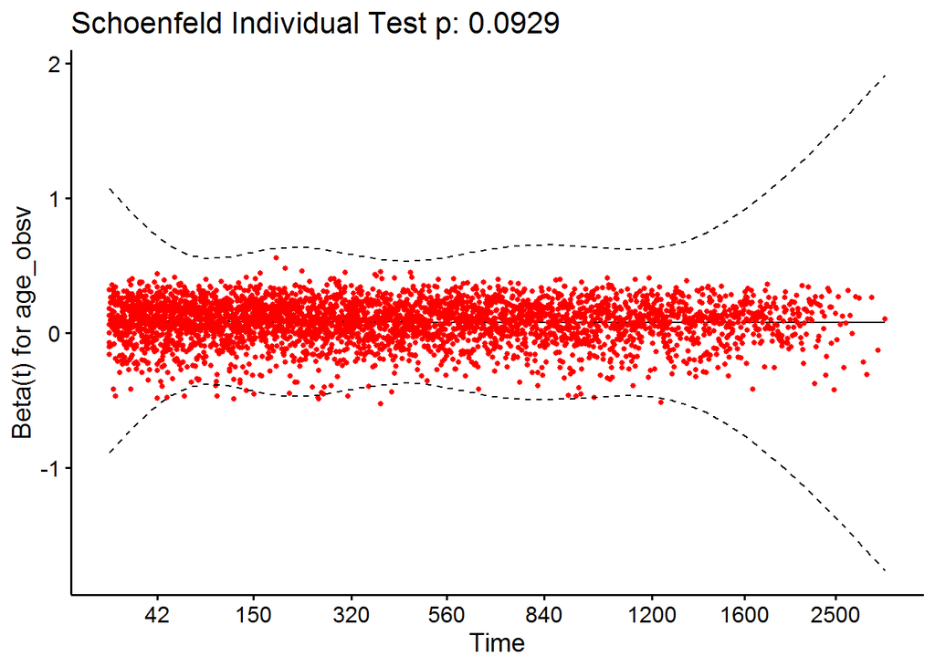

```r
ggcoxzph(resm9)[3]
```

```
## $`3`
```

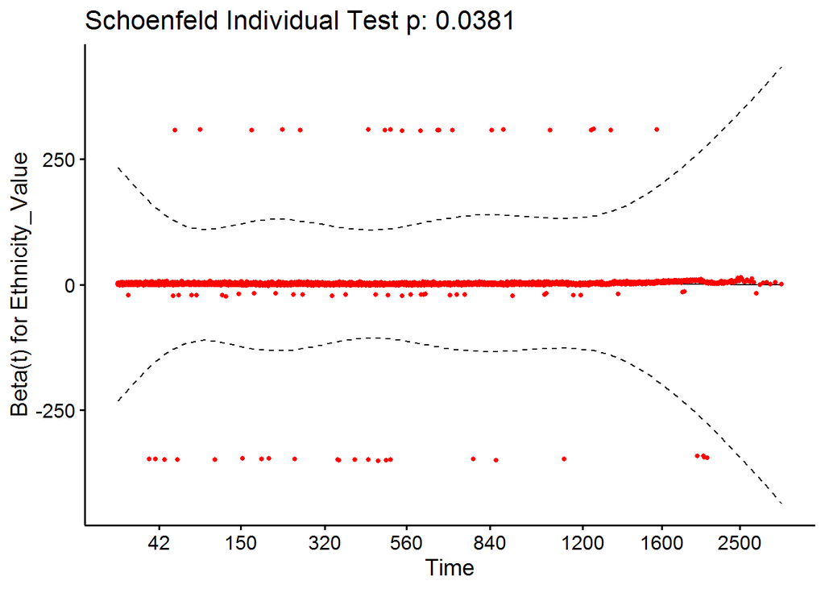

```r
anova(cox_m9)
```

```
## Analysis of Deviance Table
##  Cox model: response is Surv(time1, time2, event_death)
## Terms added sequentially (first to last)
##
##                 loglik     Chisq Df Pr(>|Chi|)
## NULL            -28378
## Gender_Value    -28378    0.0952  1     0.7576
## age_obsv        -27814 1127.8718  1     <2e-16 ***
## Ethnicity_Value -27813    2.8688  3     0.4123
## ---
## Signif. codes:  0 '***' 0.001 '**' 0.01 '*' 0.05 '.' 0.1 ' ' 1
```

**Gender, age at observation, and dementia medication class**

```r
cox_m10 <- coxph(Surv(time1, time2, event_death) ~ Gender_Value + age_obsv + type_medclass, data = all_df)

summary(cox_m10)
```

```
## Call:
## coxph(formula = Surv(time1, time2, event_death) ~ Gender_Value +
##     age_obsv + type_medclass, data = all_df)
##
##   n= 41752, number of events= 3046
##    (17221 observations deleted due to missingness)
##
##                            coef exp(coef) se(coef)     z Pr(>|z|)
## Gender_ValueMale       0.166972  1.181721 0.037439  4.46  8.2e-06 ***
## age_obsv               0.080044  1.083335 0.002955 27.09  < 2e-16 ***
## type_medclassMementine 0.667928  1.950193 0.047445 14.08  < 2e-16 ***
## ---
## Signif. codes:  0 '***' 0.001 '**' 0.01 '*' 0.05 '.' 0.1 ' ' 1
##
##                        exp(coef) exp(-coef) lower .95 upper .95
## Gender_ValueMale           1.182     0.8462     1.098     1.272
## age_obsv                   1.083     0.9231     1.077     1.090
## type_medclassMementine     1.950     0.5128     1.777     2.140
##
## Concordance= 0.669  (se = 0.006 )
## Likelihood ratio test= 971.8  on 3 df,   p=<2e-16
## Wald test            = 950.4  on 3 df,   p=<2e-16
## Score (logrank) test = 958.4  on 3 df,   p=<2e-16
```

```r
cox.zph(cox_m10)
```

```
##                chisq df       p
## Gender_Value   0.108  1   0.742
## age_obsv      15.203  1 9.7e-05
## type_medclass  0.462  1   0.497
## GLOBAL        16.227  3   0.001
```

```r
resm10 <- cox.zph(cox_m10)

ggcoxzph(resm10)[1]
```

```
## $`1`
```

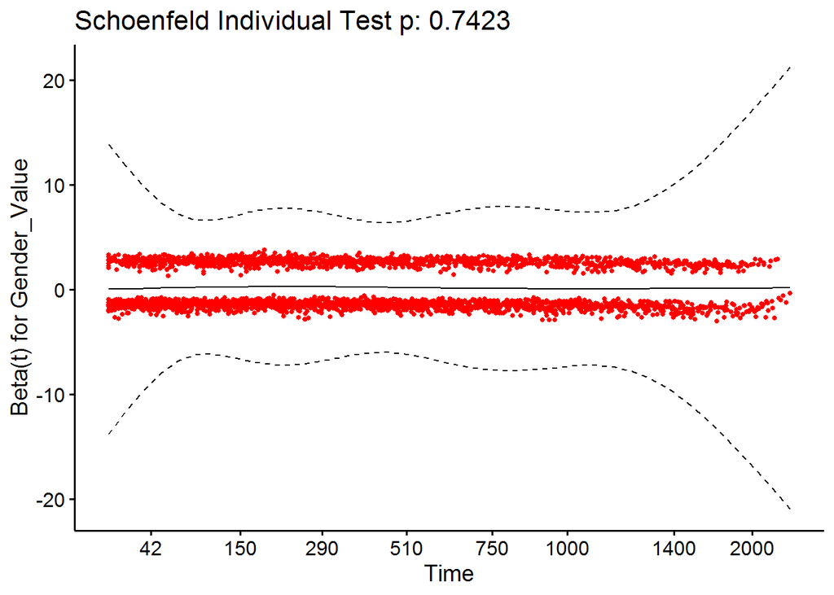

```r
ggcoxzph(resm10)[2]
```

```
## $`2`
```

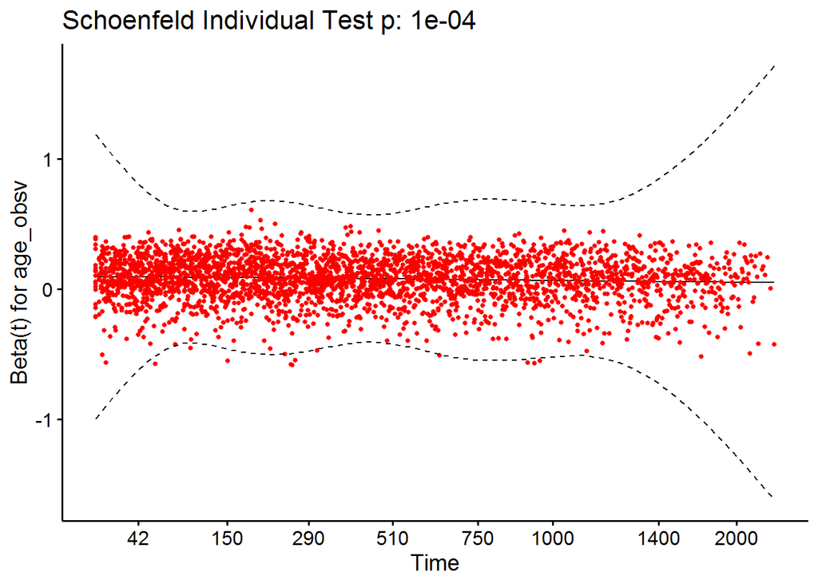

```r
ggcoxzph(resm10)[3]
```

```
## $`3`
```

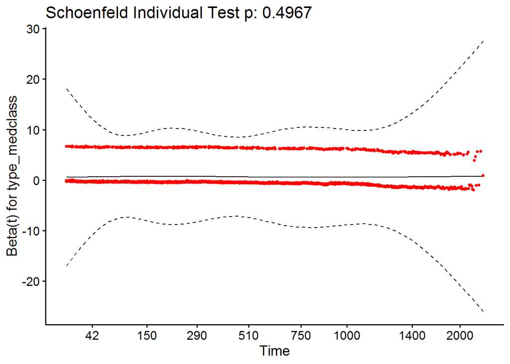

```r
anova(cox_m10)
```

```
## Analysis of Deviance Table
##  Cox model: response is Surv(time1, time2, event_death)
## Terms added sequentially (first to last)
##
##               loglik    Chisq Df Pr(>|Chi|)
## NULL          -23010
## Gender_Value  -23010   0.1456  1     0.7028
## age_obsv      -22611 799.6545  1     <2e-16 ***
## type_medclass -22525 172.0393  1     <2e-16 ***
## ---
## Signif. codes:  0 '***' 0.001 '**' 0.01 '*' 0.05 '.' 0.1 ' ' 1
```

Based on proportionality test, we removed age at observation

**Gender and dementia medication class**

```r
cox_m10a <- coxph(Surv(time1, time2, event_death) ~ Gender_Value + type_medclass, data = all_df)

summary(cox_m10a)
```

```
## Call:
## coxph(formula = Surv(time1, time2, event_death) ~ Gender_Value +
##     type_medclass, data = all_df)
##
##   n= 41752, number of events= 3046
##    (17221 observations deleted due to missingness)
##
##                           coef exp(coef) se(coef)     z Pr(>|z|)
## Gender_ValueMale       0.01551   1.01563  0.03691  0.42    0.674
## type_medclassMementine 0.67182   1.95780  0.04747 14.15   <2e-16 ***
## ---
## Signif. codes:  0 '***' 0.001 '**' 0.01 '*' 0.05 '.' 0.1 ' ' 1
##
##                        exp(coef) exp(-coef) lower .95 upper .95
## Gender_ValueMale           1.016     0.9846    0.9448     1.092
## type_medclassMementine     1.958     0.5108    1.7838     2.149
##
## Concordance= 0.536  (se = 0.006 )
## Likelihood ratio test= 173.9  on 2 df,   p=<2e-16
## Wald test            = 200.4  on 2 df,   p=<2e-16
## Score (logrank) test = 207.8  on 2 df,   p=<2e-16
```

```r
cox.zph(cox_m10a)
```

```
##               chisq df    p
## Gender_Value  0.114  1 0.74
## type_medclass 2.278  1 0.13
## GLOBAL        2.406  2 0.30
```

```r
resm10a <- cox.zph(cox_m10a)

ggcoxzph(resm10a)[1]
```

```
## $`1`
```

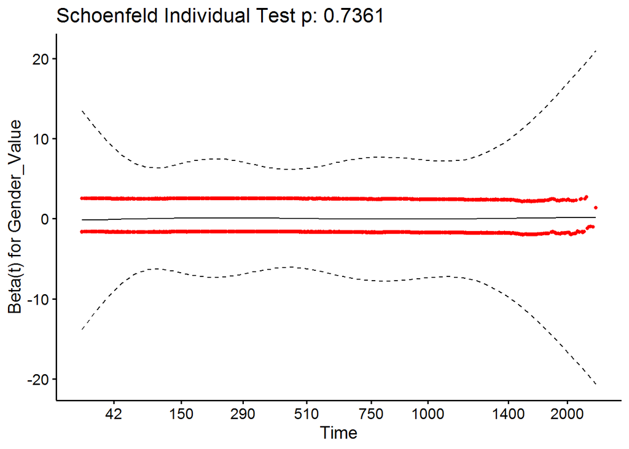

```r
ggcoxzph(resm10a)[2]
```

```
## $`2`
```

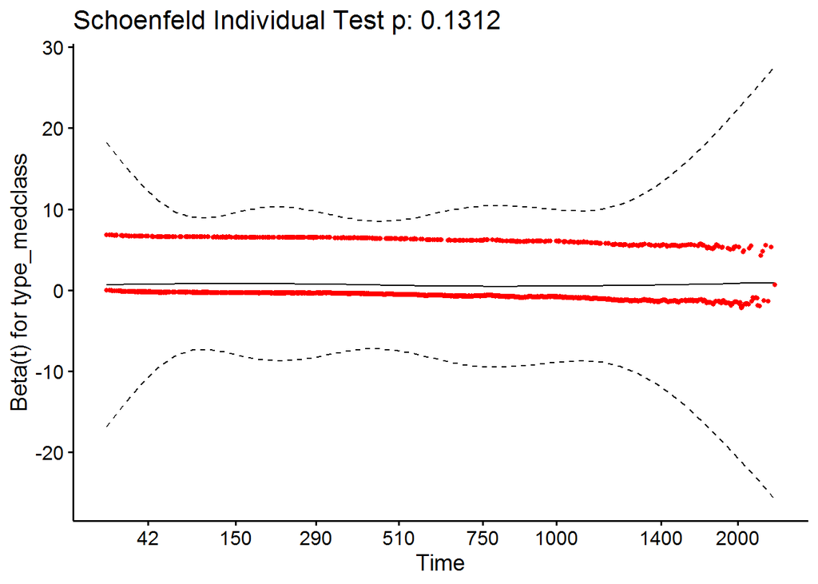

```r
anova(cox_m10)
```

```
## Analysis of Deviance Table
##  Cox model: response is Surv(time1, time2, event_death)
## Terms added sequentially (first to last)
##
##               loglik    Chisq Df Pr(>|Chi|)
## NULL          -23010
## Gender_Value  -23010   0.1456  1     0.7028
## age_obsv      -22611 799.6545  1     <2e-16 ***
## type_medclass -22525 172.0393  1     <2e-16 ***
## ---
## Signif. codes:  0 '***' 0.001 '**' 0.01 '*' 0.05 '.' 0.1 ' ' 1
```

Gender was not a significant predictor in the model above, so if we remove it we’re back to a univariate model

**Gender, age at observation, and marital_status**

```r
cox_m11 <- coxph(Surv(time1, time2, event_death) ~ Gender_Value + age_obsv + marital_status, data = all_df)

summary(cox_m11)
```

```
## Call:
## coxph(formula = Surv(time1, time2, event_death) ~ Gender_Value +
##     age_obsv + marital_status, data = all_df)
##
##   n= 36764, number of events= 2891
##    (22209 observations deleted due to missingness)
##
##                                      coef exp(coef) se(coef)      z Pr(>|z|)
## Gender_ValueMale                 0.201716  1.223501 0.040601  4.968 6.75e-07
## age_obsv                         0.081026  1.084399 0.002959 27.386  < 2e-16
## marital_statusDivorced/Separated 0.009962  1.010011 0.103134  0.097    0.923
## marital_statusSingle             0.107519  1.113512 0.075159  1.431    0.153
## marital_statusWidowed            0.061333  1.063253 0.043957  1.395    0.163
##
## Gender_ValueMale                 ***
## age_obsv                         ***
## marital_statusDivorced/Separated
## marital_statusSingle
## marital_statusWidowed
## ---
## Signif. codes:  0 '***' 0.001 '**' 0.01 '*' 0.05 '.' 0.1 ' ' 1
##
##                                  exp(coef) exp(-coef) lower .95 upper .95
## Gender_ValueMale                     1.224     0.8173    1.1299     1.325
## age_obsv                             1.084     0.9222    1.0781     1.091
## marital_statusDivorced/Separated     1.010     0.9901    0.8252     1.236
## marital_statusSingle                 1.114     0.8981    0.9610     1.290
## marital_statusWidowed                1.063     0.9405    0.9755     1.159
##
## Concordance= 0.664  (se = 0.006 )
## Likelihood ratio test= 942.2  on 5 df,   p=<2e-16
## Wald test            = 841.8  on 5 df,   p=<2e-16
## Score (logrank) test = 858.6  on 5 df,   p=<2e-16
```

```r
cox.zph(cox_m11)
```

```
##                  chisq df    p
## Gender_Value   0.00336  1 0.95
## age_obsv       2.55755  1 0.11
## marital_status 5.19263  3 0.16
## GLOBAL         7.25067  5 0.20
```

```r
resm11 <- cox.zph(cox_m11)

ggcoxzph(resm11)[1]
```

```
## $`1`
```

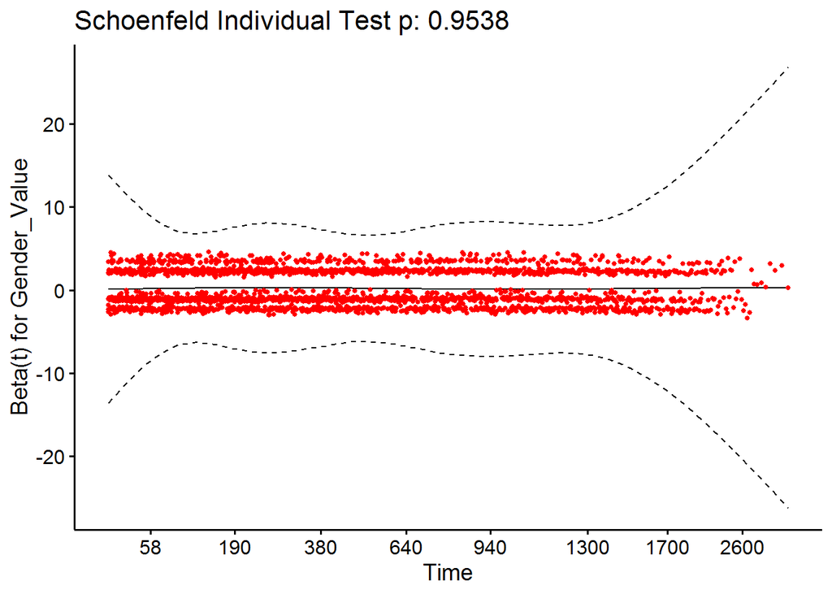

```r
ggcoxzph(resm11)[2]
```

```
## $`2`
```

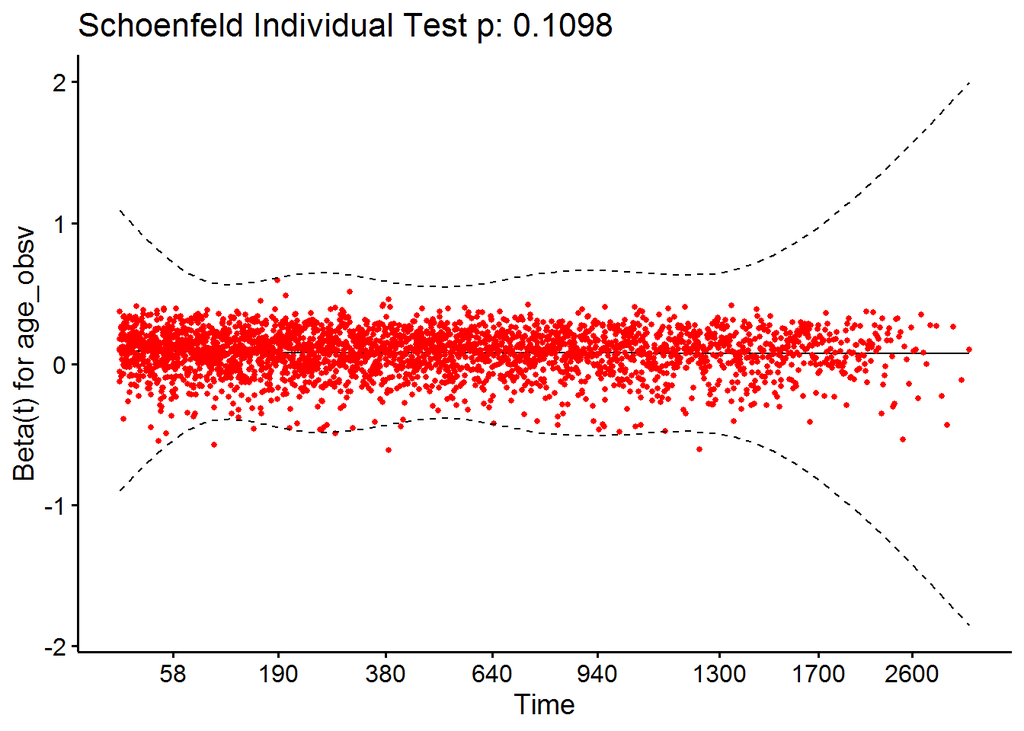

```r
ggcoxzph(resm11)[3]
```

```
## $`3`
```

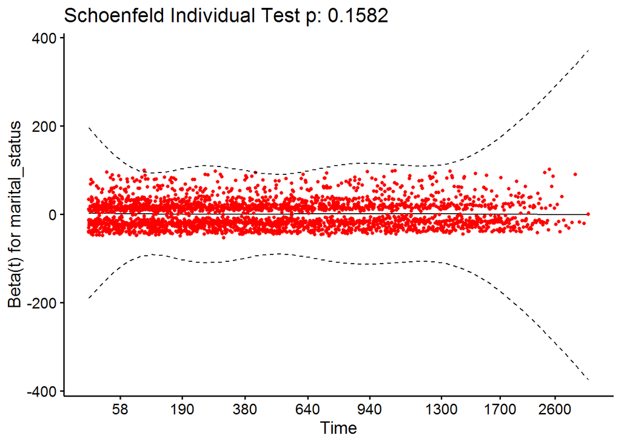

```r
anova(cox_m11)
```

```
## Analysis of Deviance Table
##  Cox model: response is Surv(time1, time2, event_death)
## Terms added sequentially (first to last)
##
##                loglik    Chisq Df Pr(>|Chi|)
## NULL           -22008
## Gender_Value   -22008   0.6348  1     0.4256
## age_obsv       -21538 938.4137  1     <2e-16 ***
## marital_status -21537   3.1678  3     0.3665
## ---
## Signif. codes:  0 '***' 0.001 '**' 0.01 '*' 0.05 '.' 0.1 ' ' 1
```

**Gender, age at observation, and type of cognitive assessment**

```r
cox_m12 <- coxph(Surv(time1, time2, event_death) ~ Gender_Value + age_obsv + type_cogeval, data = all_df)

summary(cox_m12)
```

```
## Call:
## coxph(formula = Surv(time1, time2, event_death) ~ Gender_Value +
##     age_obsv + type_cogeval, data = all_df)
##
##   n= 23797, number of events= 2309
##    (35176 observations deleted due to missingness)
##
##                      coef exp(coef) se(coef)      z Pr(>|z|)
## Gender_ValueMale 0.193617  1.213631 0.042981  4.505 6.65e-06 ***
## age_obsv         0.084257  1.087909 0.003309 25.461  < 2e-16 ***
## type_cogevalMOCA 0.057583  1.059273 0.046388  1.241    0.214
## ---
## Signif. codes:  0 '***' 0.001 '**' 0.01 '*' 0.05 '.' 0.1 ' ' 1
##
##                  exp(coef) exp(-coef) lower .95 upper .95
## Gender_ValueMale     1.214     0.8240    1.1156     1.320
## age_obsv             1.088     0.9192    1.0809     1.095
## type_cogevalMOCA     1.059     0.9440    0.9672     1.160
##
## Concordance= 0.657  (se = 0.007 )
## Likelihood ratio test= 713.6  on 3 df,   p=<2e-16
## Wald test            = 648.6  on 3 df,   p=<2e-16
## Score (logrank) test = 656.8  on 3 df,   p=<2e-16
```

```r
cox.zph(cox_m12)
```

```
##               chisq df    p
## Gender_Value 0.2463  1 0.62
## age_obsv     0.2901  1 0.59
## type_cogeval 0.0094  1 0.92
## GLOBAL       0.4801  3 0.92
```

```r
resm12 <- cox.zph(cox_m12)

ggcoxzph(resm12)[1]
```

```
## $`1`
```

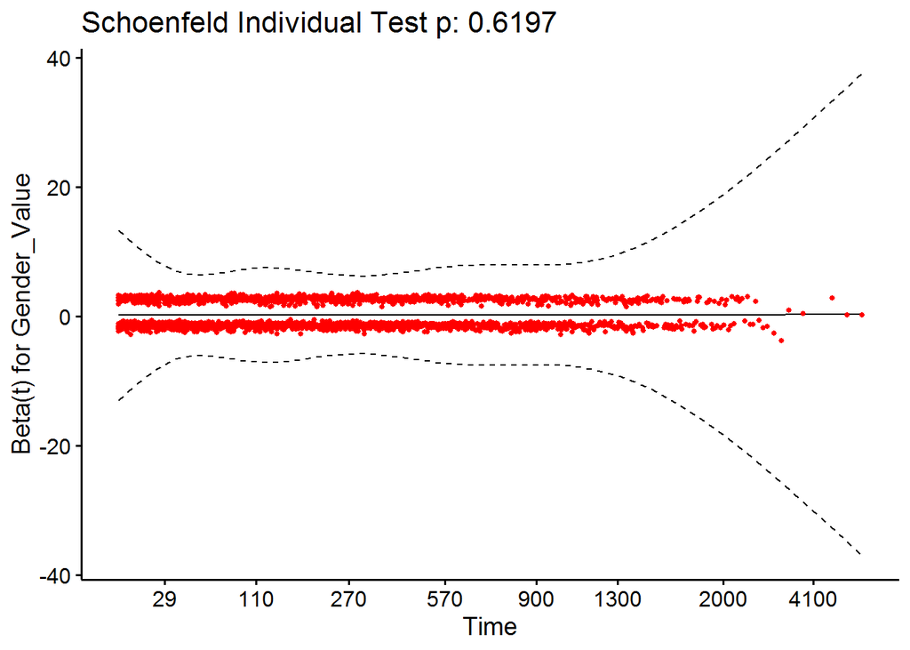

```r
ggcoxzph(resm12)[2]
```

```
## $`2`
```

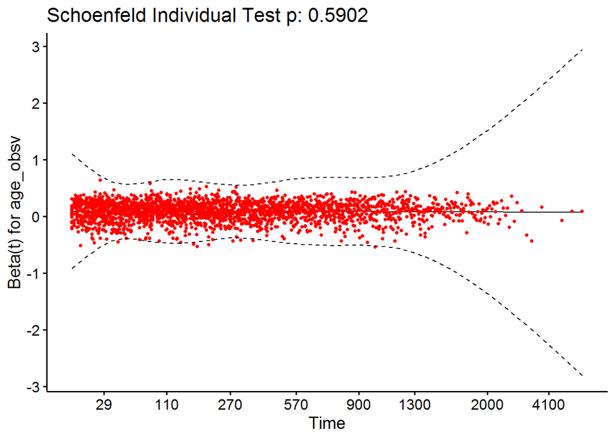

```r
ggcoxzph(resm12)[3]
```

```
## $`3`
```

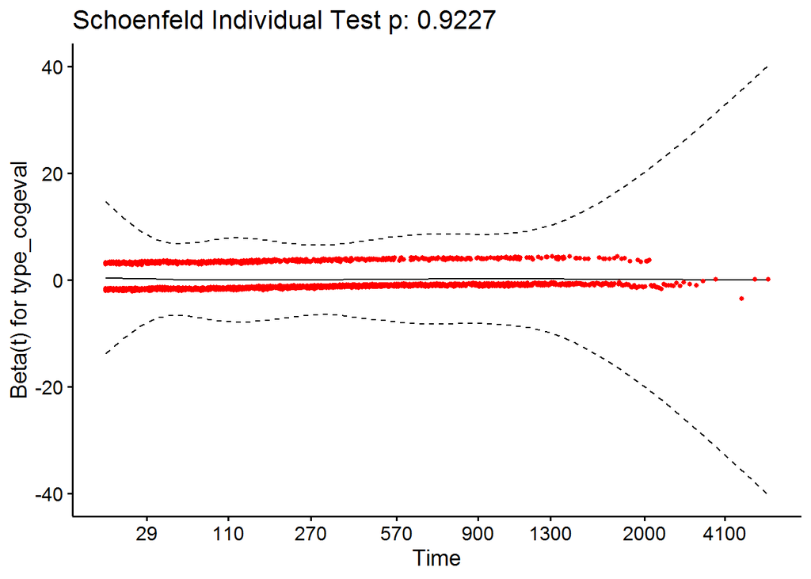

```r
anova(cox_m12)
```

```
## Analysis of Deviance Table
##  Cox model: response is Surv(time1, time2, event_death)
## Terms added sequentially (first to last)
##
##              loglik    Chisq Df Pr(>|Chi|)
## NULL         -17559
## Gender_Value -17559   0.1702  1     0.6799
## age_obsv     -17203 711.8919  1     <2e-16 ***
## type_cogeval -17202   1.5292  1     0.2162
## ---
## Signif. codes:  0 '***' 0.001 '**' 0.01 '*' 0.05 '.' 0.1 ' ' 1
```

**Gender, age at observation, and score in cognitive assessment**

```r
cox_m13 <- coxph(Surv(time1, time2, event_death) ~ Gender_Value + age_obsv + numerator, data = all_df)

summary(cox_m13)
```

```
## Call:
## coxph(formula = Surv(time1, time2, event_death) ~ Gender_Value +
##     age_obsv + numerator, data = all_df)
##
##   n= 23797, number of events= 2309
##    (35176 observations deleted due to missingness)
##
##                       coef exp(coef)  se(coef)       z Pr(>|z|)
## Gender_ValueMale  0.216201  1.241352  0.042935   5.036 4.76e-07 ***
## age_obsv          0.080713  1.084059  0.003301  24.451  < 2e-16 ***
## numerator        -0.040464  0.960343  0.002919 -13.864  < 2e-16 ***
## ---
## Signif. codes:  0 '***' 0.001 '**' 0.01 '*' 0.05 '.' 0.1 ' ' 1
##
##                  exp(coef) exp(-coef) lower .95 upper .95
## Gender_ValueMale    1.2414     0.8056    1.1412    1.3503
## age_obsv            1.0841     0.9225    1.0771    1.0911
## numerator           0.9603     1.0413    0.9549    0.9659
##
## Concordance= 0.674  (se = 0.007 )
## Likelihood ratio test= 893.9  on 3 df,   p=<2e-16
## Wald test            = 833  on 3 df,   p=<2e-16
## Score (logrank) test = 840.7  on 3 df,   p=<2e-16
```

```r
cox.zph(cox_m13)
```

```
##               chisq df    p
## Gender_Value 0.0324  1 0.86
## age_obsv     0.3497  1 0.55
## numerator    1.1052  1 0.29
## GLOBAL       1.5774  3 0.66
```

```r
resm13 <- cox.zph(cox_m13)

ggcoxzph(resm13)[1]
```

```
## $`1`
```

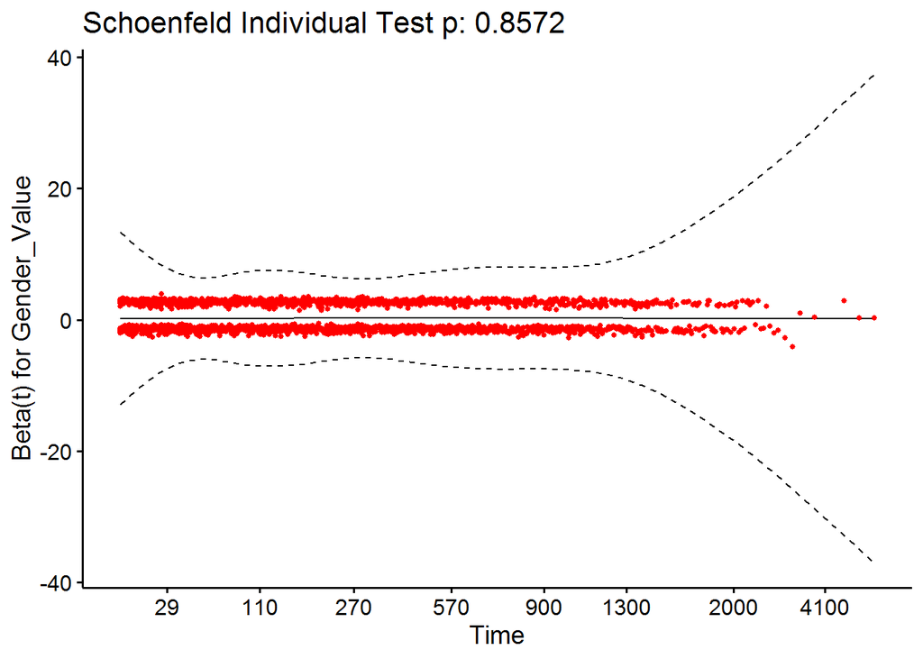

```r
ggcoxzph(resm13)[2]
```

```
## $`2`
```

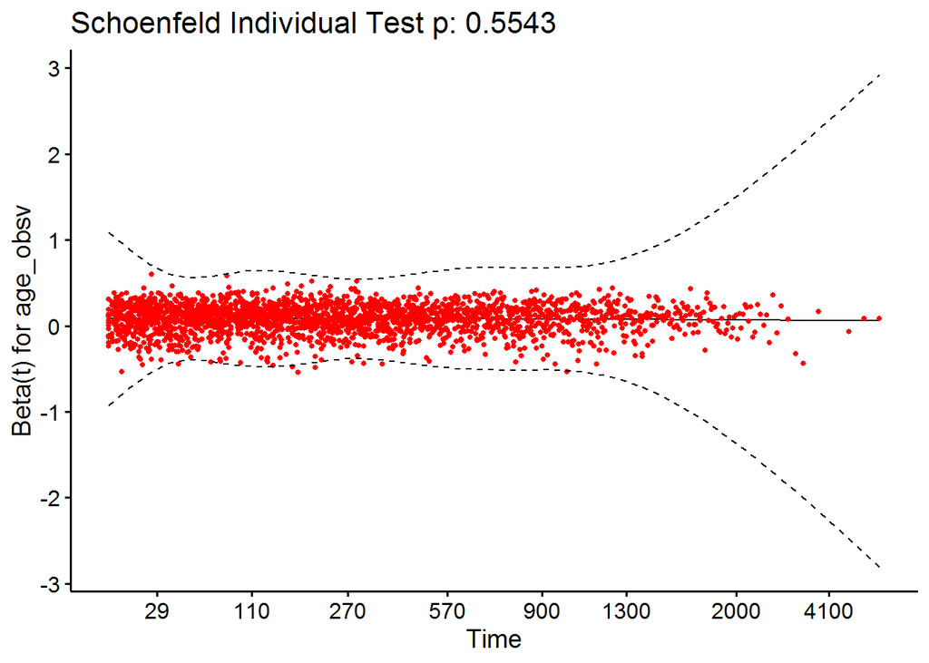

```r
ggcoxzph(resm13)[3]
```

```
## $`3`
```

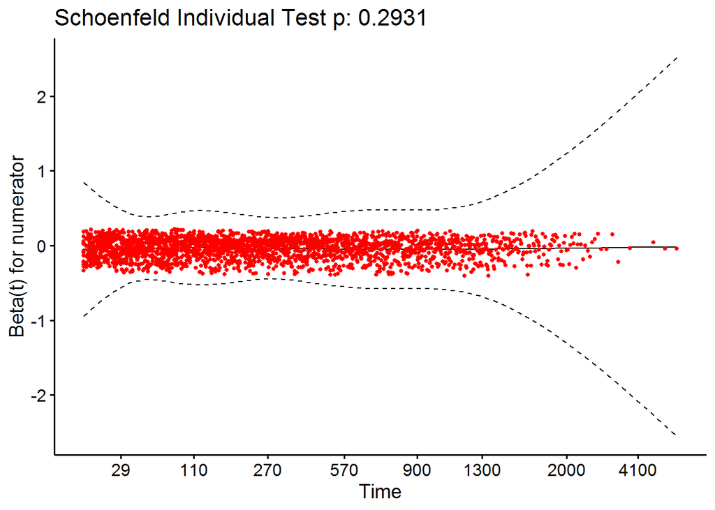

```r
anova(cox_m13)
```

```
## Analysis of Deviance Table
##  Cox model: response is Surv(time1, time2, event_death)
## Terms added sequentially (first to last)
##
##              loglik    Chisq Df Pr(>|Chi|)
## NULL         -17559
## Gender_Value -17559   0.1702  1     0.6799
## age_obsv     -17203 711.8919  1     <2e-16 ***
## numerator    -17112 181.8660  1     <2e-16 ***
## ---
## Signif. codes:  0 '***' 0.001 '**' 0.01 '*' 0.05 '.' 0.1 ' ' 1
```

*Forest plot*

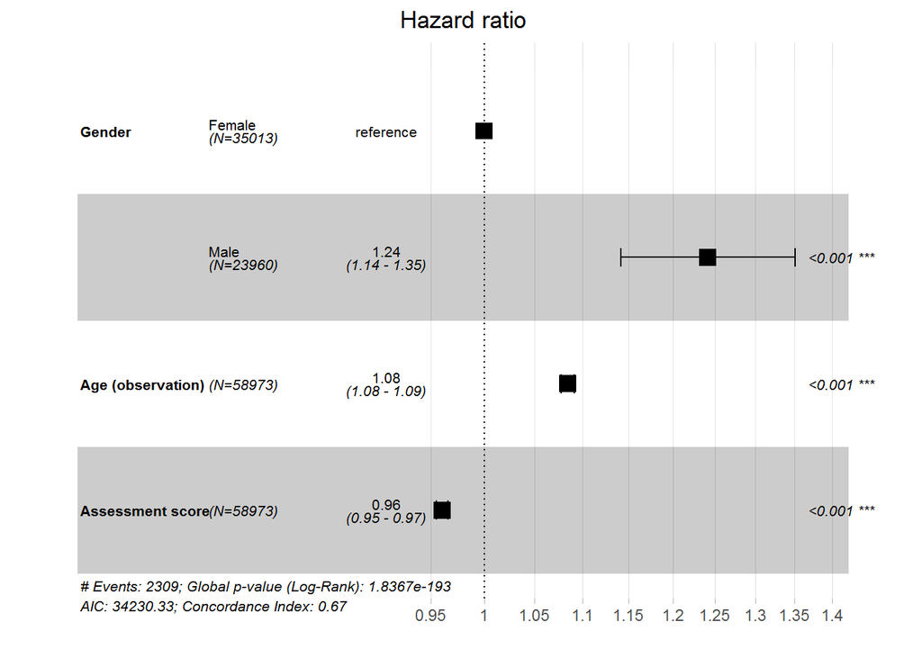

```r
forest_df13 <- all_df %>%
  transmute(time1,
            time2,
            event_death,
            Gender = factor(Gender_Value),
            `Age (observation)` = age_obsv,
            `Assessment score` = numerator) %>%
  mutate(Gender = relevel(Gender, ref = "Female"))

new13 <- coxph(Surv(time1, time2, event_death) ~ Gender + `Age (observation)` + `Assessment score`, data = forest_df13)

ggforest(new13,
         cpositions = c(0.003, 0.17, 0.4))
```

**Gender, age at observation, and chronic medication use**

```r
cox_m14 <- coxph(Surv(time1, time2, event_death) ~ Gender_Value + age_obsv + medother_grouped, data = all_df)

summary(cox_m14)
```

```
## Call:
## coxph(formula = Surv(time1, time2, event_death) ~ Gender_Value +
##     age_obsv + medother_grouped, data = all_df)
##
##   n= 17400, number of events= 1150
##    (41573 observations deleted due to missingness)
##
##                                coef exp(coef)  se(coef)      z Pr(>|z|)
## Gender_ValueMale           0.345727  1.413017  0.061475  5.624 1.87e-08 ***
## age_obsv                   0.068538  1.070941  0.004379 15.652  < 2e-16 ***
## medother_groupedInsulin   -0.269120  0.764051  0.167639 -1.605 0.108417
## medother_groupedSNRIs     -0.429492  0.650840  0.207617 -2.069 0.038577 *
## medother_groupedSSRIs     -0.316190  0.728921  0.078250 -4.041 5.33e-05 ***
## medother_groupedTCAs      -0.559951  0.571237  0.185722 -3.015 0.002570 **
## medother_groupedTeCAs     -0.333995  0.716057  0.100627 -3.319 0.000903 ***
## medother_groupedTrazodone  0.066423  1.068678  0.083595  0.795 0.426862
## ---
## Signif. codes:  0 '***' 0.001 '**' 0.01 '*' 0.05 '.' 0.1 ' ' 1
##
##                           exp(coef) exp(-coef) lower .95 upper .95
## Gender_ValueMale             1.4130     0.7077    1.2526    1.5940
## age_obsv                     1.0709     0.9338    1.0618    1.0802
## medother_groupedInsulin      0.7641     1.3088    0.5501    1.0612
## medother_groupedSNRIs        0.6508     1.5365    0.4333    0.9777
## medother_groupedSSRIs        0.7289     1.3719    0.6253    0.8497
## medother_groupedTCAs         0.5712     1.7506    0.3969    0.8221
## medother_groupedTeCAs        0.7161     1.3965    0.5879    0.8722
## medother_groupedTrazodone    1.0687     0.9357    0.9072    1.2589
##
## Concordance= 0.655  (se = 0.009 )
## Likelihood ratio test= 323.2  on 8 df,   p=<2e-16
## Wald test            = 306.9  on 8 df,   p=<2e-16
## Score (logrank) test = 310.9  on 8 df,   p=<2e-16
```

```r
cox.zph(cox_m14)
```

```
##                  chisq df    p
## Gender_Value      1.51  1 0.22
## age_obsv          0.15  1 0.70
## medother_grouped  7.08  6 0.31
## GLOBAL            8.83  8 0.36
```

```r
resm14 <- cox.zph(cox_m14)

ggcoxzph(resm14)[1]
```

```
## $`1`
```

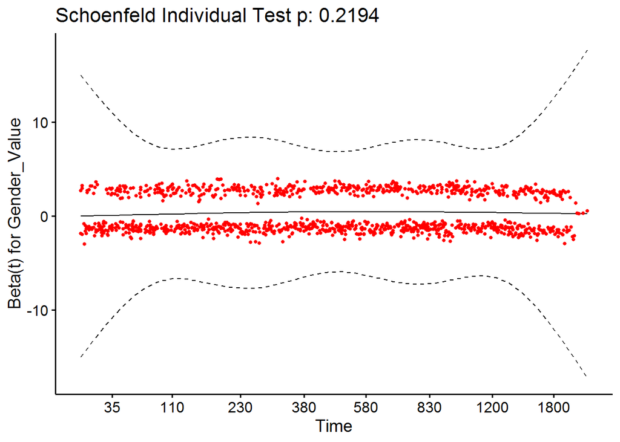

```r
ggcoxzph(resm14)[2]
```

```
## $`2`
```

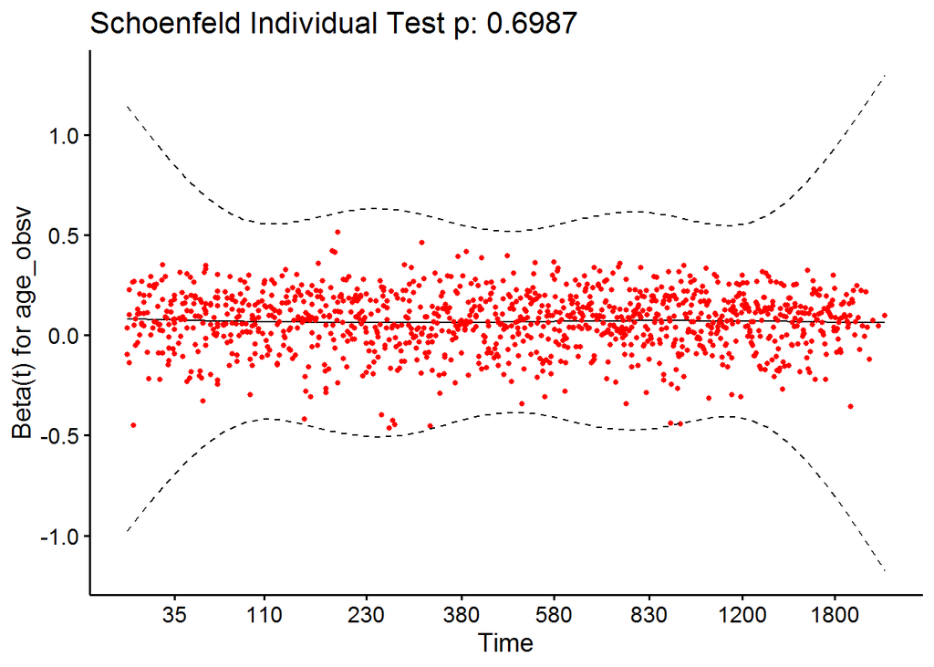

```r
ggcoxzph(resm14)[3]
```

```
## $`3`
```

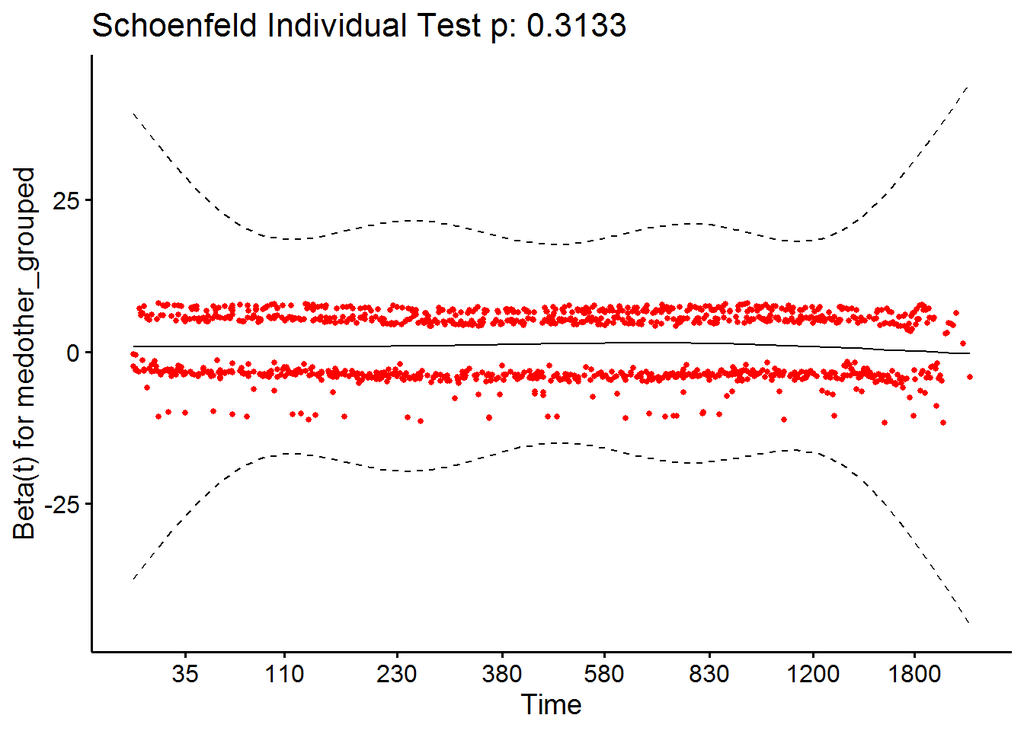

```r
anova(cox_m14)
```

```
## Analysis of Deviance Table
##  Cox model: response is Surv(time1, time2, event_death)
## Terms added sequentially (first to last)
##
##                   loglik   Chisq Df Pr(>|Chi|)
## NULL             -7099.9
## Gender_Value     -7094.5  10.801  1   0.001014 **
## age_obsv         -6958.8 271.485  1  < 2.2e-16 ***
## medother_grouped -6938.3  40.941  6  2.974e-07 ***
## ---
## Signif. codes:  0 '***' 0.001 '**' 0.01 '*' 0.05 '.' 0.1 ' ' 1
```

*Forest plot*

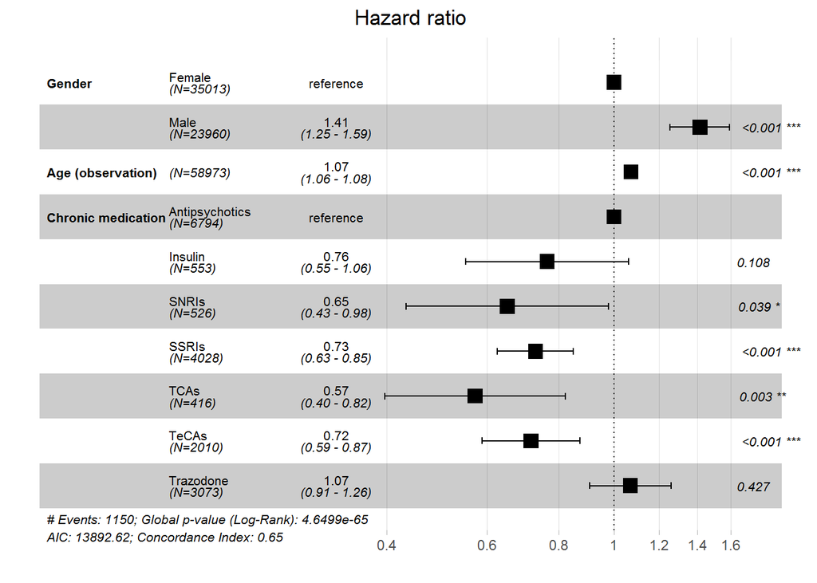

```r
forest_df14 <- all_df %>%
  transmute(time1,
            time2,
            event_death,
            Gender = factor(Gender_Value),
            `Age (observation)` = age_obsv,
            `Chronic medication` = medother_grouped) %>%
  mutate(Gender = relevel(Gender, ref = "Female"))

new14 <- coxph(Surv(time1, time2, event_death) ~ Gender + `Age (observation)` + `Chronic medication`, data = forest_df14)

ggforest(new14,
         cpositions = c(0.01, 0.175, 0.4))
```

**Gender, age at observation, marital status, and score in cognitive assessment**

```r
cox_m15 <- coxph(Surv(time1, time2, event_death) ~ Gender_Value + age_obsv + marital_status + numerator, data = all_df)

summary(cox_m15)
```

```
## Call:
## coxph(formula = Surv(time1, time2, event_death) ~ Gender_Value +
##     age_obsv + marital_status + numerator, data = all_df)
##
##   n= 14591, number of events= 1240
##    (44382 observations deleted due to missingness)
##
##                                       coef exp(coef)  se(coef)      z Pr(>|z|)
## Gender_ValueMale                  0.256750  1.292722  0.062863  4.084 4.42e-05
## age_obsv                          0.082182  1.085654  0.004735 17.358  < 2e-16
## marital_statusDivorced/Separated  0.289221  1.335387  0.152630  1.895 0.058103
## marital_statusSingle              0.397708  1.488409  0.111737  3.559 0.000372
## marital_statusWidowed             0.190336  1.209655  0.068151  2.793 0.005225
## numerator                        -0.040824  0.959998  0.004136 -9.869  < 2e-16
##
## Gender_ValueMale                 ***
## age_obsv                         ***
## marital_statusDivorced/Separated .
## marital_statusSingle             ***
## marital_statusWidowed            **
## numerator                        ***
## ---
## Signif. codes:  0 '***' 0.001 '**' 0.01 '*' 0.05 '.' 0.1 ' ' 1
##
##                                  exp(coef) exp(-coef) lower .95 upper .95
## Gender_ValueMale                     1.293     0.7736    1.1429    1.4622
## age_obsv                             1.086     0.9211    1.0756    1.0958
## marital_statusDivorced/Separated     1.335     0.7488    0.9901    1.8011
## marital_statusSingle                 1.488     0.6719    1.1957    1.8528
## marital_statusWidowed                1.210     0.8267    1.0584    1.3825
## numerator                            0.960     1.0417    0.9522    0.9678
##
## Concordance= 0.681  (se = 0.009 )
## Likelihood ratio test= 530.4  on 6 df,   p=<2e-16
## Wald test            = 490.2  on 6 df,   p=<2e-16
## Score (logrank) test = 500.9  on 6 df,   p=<2e-16
```

```r
cox.zph(cox_m15)
```

```
##                chisq df    p
## Gender_Value   0.635  1 0.43
## age_obsv       1.025  1 0.31
## marital_status 1.074  3 0.78
## numerator      0.714  1 0.40
## GLOBAL         4.120  6 0.66
```

```r
resm15 <- cox.zph(cox_m15)

ggcoxzph(resm15)[1]
```

```
## $`1`
```

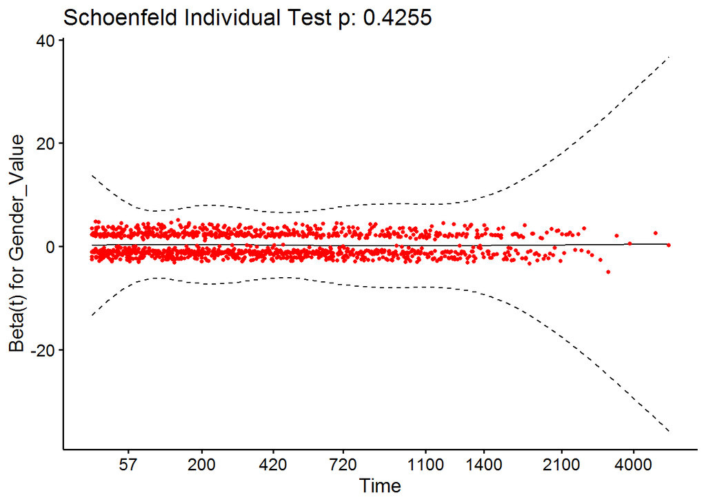

```r
ggcoxzph(resm15)[2]
```

```
## $`2`
```

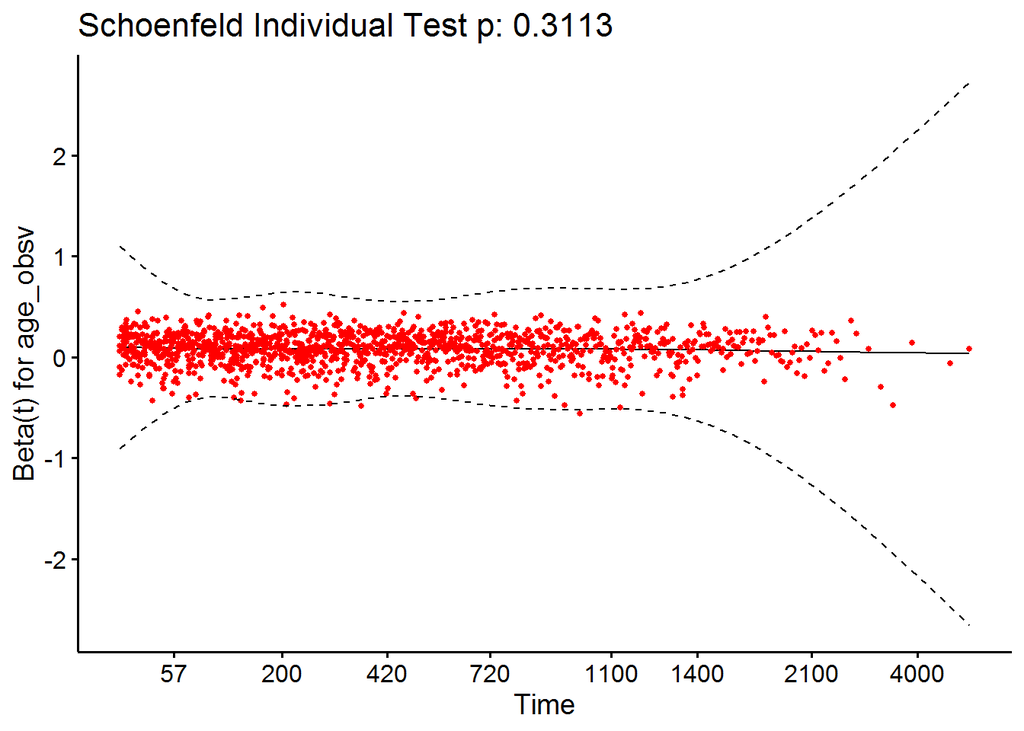

```r
ggcoxzph(resm15)[3]
```

```
## $`3`
```

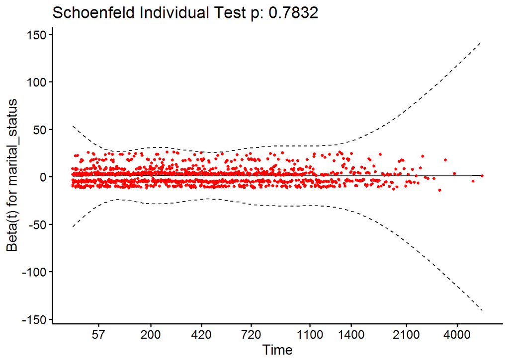

```r
ggcoxzph(resm15)[4]
```

```
## $`4`
```

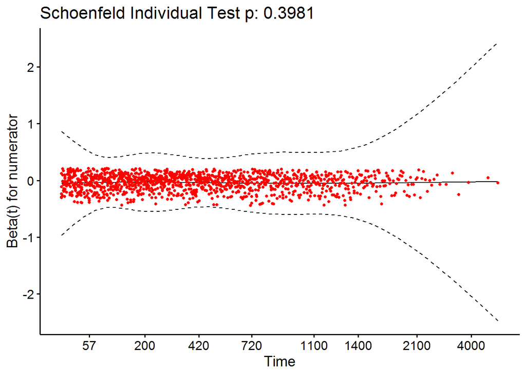

```r
anova(cox_m15)
```

```
## Analysis of Deviance Table
##  Cox model: response is Surv(time1, time2, event_death)
## Terms added sequentially (first to last)
##
##                 loglik   Chisq Df Pr(>|Chi|)
## NULL           -8642.6
## Gender_Value   -8642.5   0.172  1   0.678323
## age_obsv       -8430.6 423.837  1  < 2.2e-16 ***
## marital_status -8423.2  14.656  3   0.002135 **
## numerator      -8377.4  91.757  1  < 2.2e-16 ***
## ---
## Signif. codes:  0 '***' 0.001 '**' 0.01 '*' 0.05 '.' 0.1 ' ' 1
```

*Forest plot*

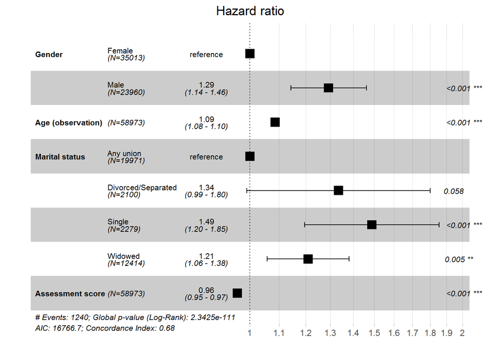

```r
forest_df15 <- all_df %>%
  transmute(time1,
            time2,
            event_death,
            Gender = factor(Gender_Value),
            `Age (observation)` = age_obsv,
            `Marital status` = marital_status,
            `Assessment score` = numerator) %>%
  mutate(Gender = relevel(Gender, ref = "Female"))

new15 <- coxph(Surv(time1, time2, event_death) ~ Gender + `Age (observation)` + `Marital status` + `Assessment score`, data = forest_df15)

ggforest(new15,
         cpositions = c(0.01, 0.175, 0.4))
```

**Gender, age at observation, marital status, and chronic medication use**

```r
cox_m16 <- coxph(Surv(time1, time2, event_death) ~  Gender_Value + age_obsv + marital_status + medother_grouped, data = all_df)

summary(cox_m16)
```

```
## Call:
## coxph(formula = Surv(time1, time2, event_death) ~ Gender_Value +
##     age_obsv + marital_status + medother_grouped, data = all_df)
##
##   n= 11038, number of events= 660
##    (47935 observations deleted due to missingness)
##
##                                      coef exp(coef) se(coef)      z Pr(>|z|)
## Gender_ValueMale                  0.37929   1.46125  0.08554  4.434 9.26e-06
## age_obsv                          0.06413   1.06623  0.00615 10.428  < 2e-16
## marital_statusDivorced/Separated -0.16225   0.85023  0.20981 -0.773   0.4394
## marital_statusSingle              0.10312   1.10863  0.16276  0.634   0.5264
## marital_statusWidowed             0.06244   1.06443  0.09305  0.671   0.5022
## medother_groupedInsulin          -0.45459   0.63471  0.26202 -1.735   0.0828
## medother_groupedSNRIs            -0.42949   0.65084  0.29914 -1.436   0.1511
## medother_groupedSSRIs            -0.27243   0.76153  0.10775 -2.528   0.0115
## medother_groupedTCAs             -0.39921   0.67085  0.22752 -1.755   0.0793
## medother_groupedTeCAs            -0.21302   0.80814  0.12961 -1.644   0.1003
## medother_groupedTrazodone         0.19865   1.21975  0.10881  1.826   0.0679
##
## Gender_ValueMale                 ***
## age_obsv                         ***
## marital_statusDivorced/Separated
## marital_statusSingle
## marital_statusWidowed
## medother_groupedInsulin          .
## medother_groupedSNRIs
## medother_groupedSSRIs            *
## medother_groupedTCAs             .
## medother_groupedTeCAs
## medother_groupedTrazodone        .
## ---
## Signif. codes:  0 '***' 0.001 '**' 0.01 '*' 0.05 '.' 0.1 ' ' 1
##
##                                  exp(coef) exp(-coef) lower .95 upper .95
## Gender_ValueMale                    1.4612     0.6843    1.2357    1.7280
## age_obsv                            1.0662     0.9379    1.0535    1.0792
## marital_statusDivorced/Separated    0.8502     1.1761    0.5636    1.2827
## marital_statusSingle                1.1086     0.9020    0.8058    1.5252
## marital_statusWidowed               1.0644     0.9395    0.8870    1.2774
## medother_groupedInsulin             0.6347     1.5755    0.3798    1.0607
## medother_groupedSNRIs               0.6508     1.5365    0.3621    1.1698
## medother_groupedSSRIs               0.7615     1.3132    0.6166    0.9406
## medother_groupedTCAs                0.6708     1.4906    0.4295    1.0478
## medother_groupedTeCAs               0.8081     1.2374    0.6269    1.0419
## medother_groupedTrazodone           1.2198     0.8198    0.9855    1.5097
##
## Concordance= 0.656  (se = 0.012 )
## Likelihood ratio test= 189.2  on 11 df,   p=<2e-16
## Wald test            = 178.9  on 11 df,   p=<2e-16
## Score (logrank) test = 182.2  on 11 df,   p=<2e-16
```

```r
cox.zph(cox_m16)
```

```
##                   chisq df    p
## Gender_Value     0.0453  1 0.83
## age_obsv         0.0686  1 0.79
## marital_status   0.3706  3 0.95
## medother_grouped 7.9891  6 0.24
## GLOBAL           8.5302 11 0.67
```

```r
resm16 <- cox.zph(cox_m16)

ggcoxzph(resm16)[1]
```

```
## $`1`
```

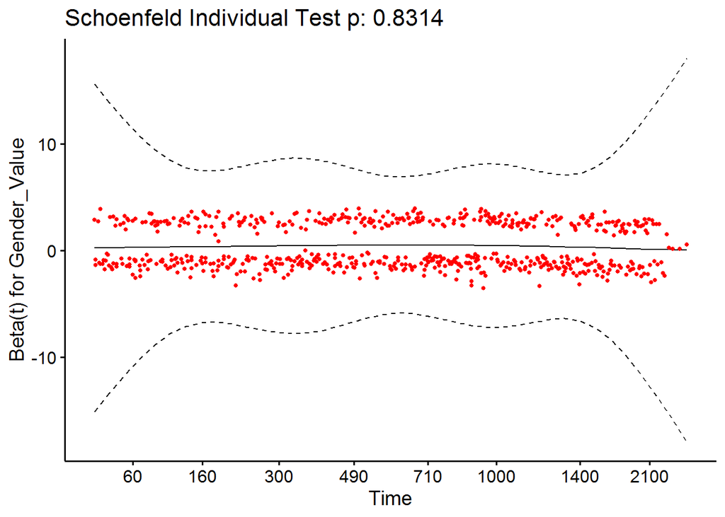

```r
ggcoxzph(resm16)[2]
```

```
## $`2`
```

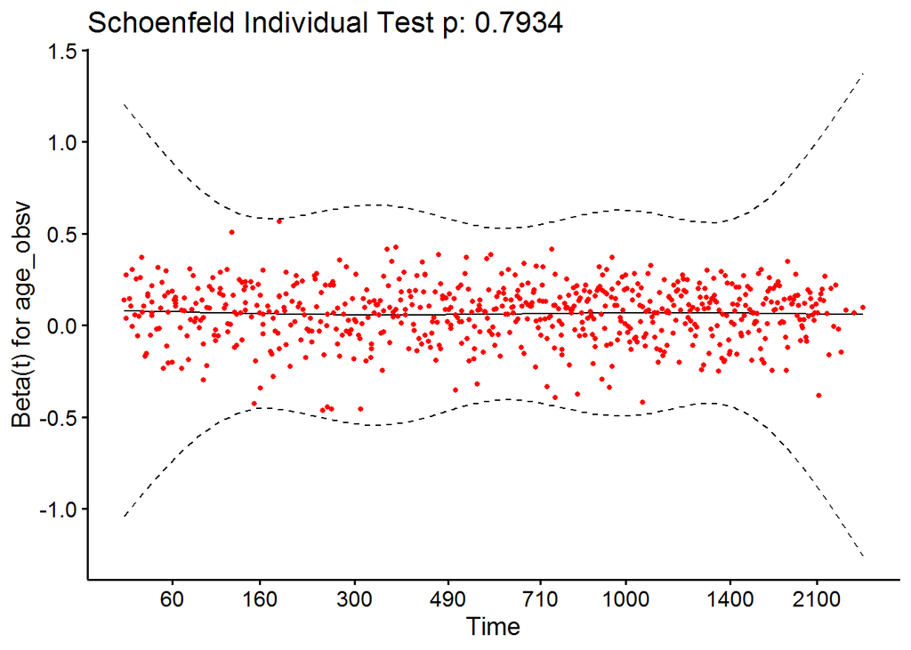

```r
ggcoxzph(resm16)[3]
```

```
## $`3`
```

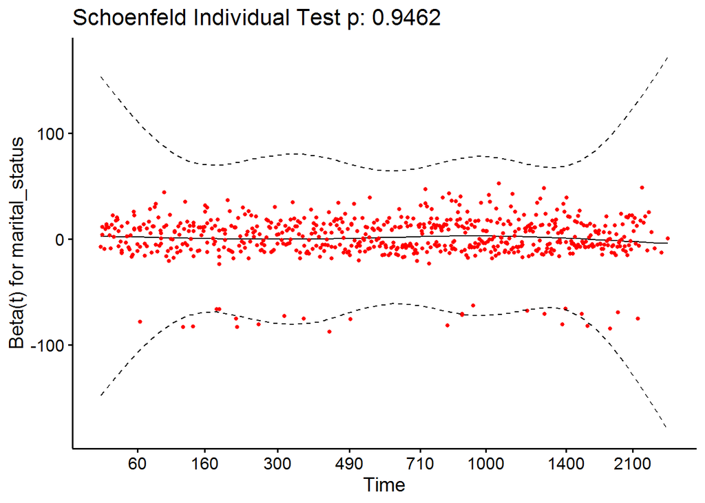

```r
ggcoxzph(resm16)[4]
```

```
## $`4`
```

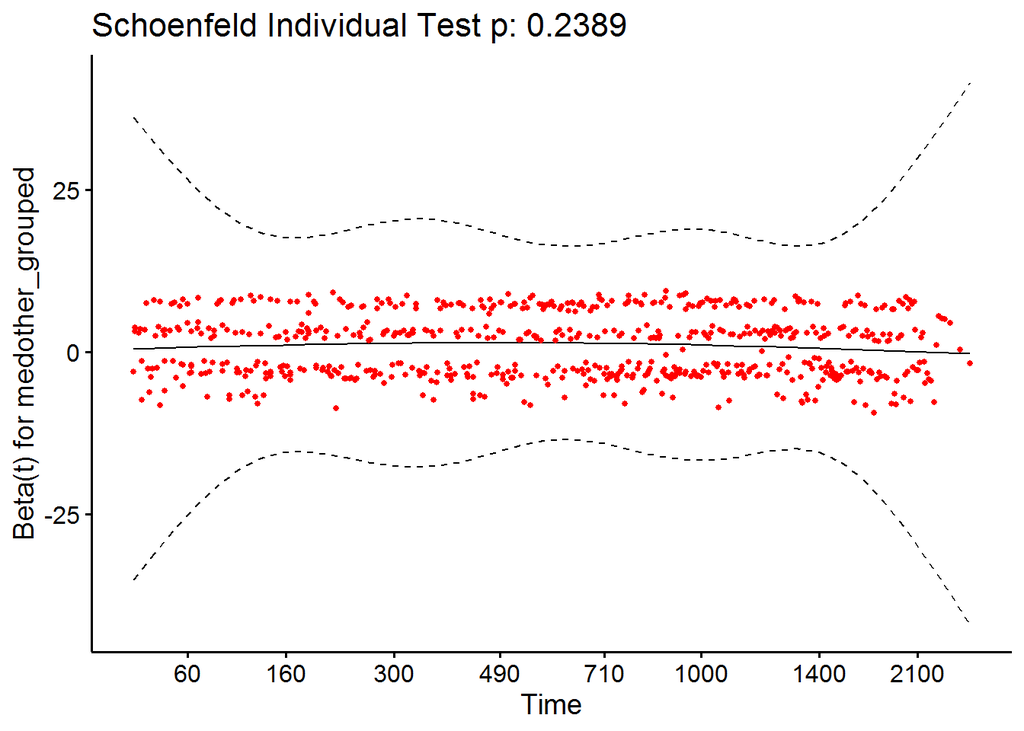

```r
anova(cox_m16)
```

```
## Analysis of Deviance Table
##  Cox model: response is Surv(time1, time2, event_death)
## Terms added sequentially (first to last)
##
##                   loglik    Chisq Df Pr(>|Chi|)
## NULL             -3709.1
## Gender_Value     -3704.7   8.7246  1  0.0031394 **
## age_obsv         -3629.2 151.0148  1  < 2.2e-16 ***
## marital_status   -3628.2   2.1479  3  0.5422885
## medother_grouped -3614.5  27.3105  6  0.0001266 ***
## ---
## Signif. codes:  0 '***' 0.001 '**' 0.01 '*' 0.05 '.' 0.1 ' ' 1
```

If remove marital status, we’re back to Gender, age at observation, and chronic medication (i.e., cox_m14)…

But we could try: **Age at observation, chronic medication, and marital_status**

```r
cox_m16a <- coxph(Surv(time1, time2, event_death) ~ age_obsv + marital_status + medother_grouped, data = all_df)

summary(cox_m16a)
```

```
## Call:
## coxph(formula = Surv(time1, time2, event_death) ~ age_obsv +
##     marital_status + medother_grouped, data = all_df)
##
##   n= 11038, number of events= 660
##    (47935 observations deleted due to missingness)
##
##                                       coef exp(coef)  se(coef)      z Pr(>|z|)
## age_obsv                          0.061636  1.063576  0.006088 10.124  < 2e-16
## marital_statusDivorced/Separated -0.248656  0.779848  0.208969 -1.190  0.23408
## marital_statusSingle              0.062352  1.064337  0.162563  0.384  0.70131
## marital_statusWidowed            -0.056458  0.945106  0.089067 -0.634  0.52615
## medother_groupedInsulin          -0.436134  0.646531  0.261940 -1.665  0.09591
## medother_groupedSNRIs            -0.439163  0.644575  0.299115 -1.468  0.14205
## medother_groupedSSRIs            -0.293792  0.745431  0.107528 -2.732  0.00629
## medother_groupedTCAs             -0.457089  0.633124  0.227045 -2.013  0.04409
## medother_groupedTeCAs            -0.217280  0.804704  0.129466 -1.678  0.09329
## medother_groupedTrazodone         0.215298  1.240232  0.108569  1.983  0.04736
##
## age_obsv                         ***
## marital_statusDivorced/Separated
## marital_statusSingle
## marital_statusWidowed
## medother_groupedInsulin          .
## medother_groupedSNRIs
## medother_groupedSSRIs            **
## medother_groupedTCAs             *
## medother_groupedTeCAs            .
## medother_groupedTrazodone        *
## ---
## Signif. codes:  0 '***' 0.001 '**' 0.01 '*' 0.05 '.' 0.1 ' ' 1
##
##                                  exp(coef) exp(-coef) lower .95 upper .95
## age_obsv                            1.0636     0.9402    1.0510    1.0763
## marital_statusDivorced/Separated    0.7798     1.2823    0.5178    1.1746
## marital_statusSingle                1.0643     0.9396    0.7739    1.4637
## marital_statusWidowed               0.9451     1.0581    0.7937    1.1254
## medother_groupedInsulin             0.6465     1.5467    0.3869    1.0803
## medother_groupedSNRIs               0.6446     1.5514    0.3586    1.1585
## medother_groupedSSRIs               0.7454     1.3415    0.6038    0.9203
## medother_groupedTCAs                0.6331     1.5795    0.4057    0.9880
## medother_groupedTeCAs               0.8047     1.2427    0.6244    1.0371
## medother_groupedTrazodone           1.2402     0.8063    1.0025    1.5343
##
## Concordance= 0.65  (se = 0.012 )
## Likelihood ratio test= 169.8  on 10 df,   p=<2e-16
## Wald test            = 162.9  on 10 df,   p=<2e-16
## Score (logrank) test = 165.9  on 10 df,   p=<2e-16
```

```r
cox.zph(cox_m16a)
```

```
##                   chisq df    p
## age_obsv         0.0151  1 0.90
## marital_status   0.2724  3 0.97
## medother_grouped 8.4312  6 0.21
## GLOBAL           8.7170 10 0.56
```

```r
resm16a <- cox.zph(cox_m16a)

ggcoxzph(resm16a)[1]
```

```
## $`1`
```

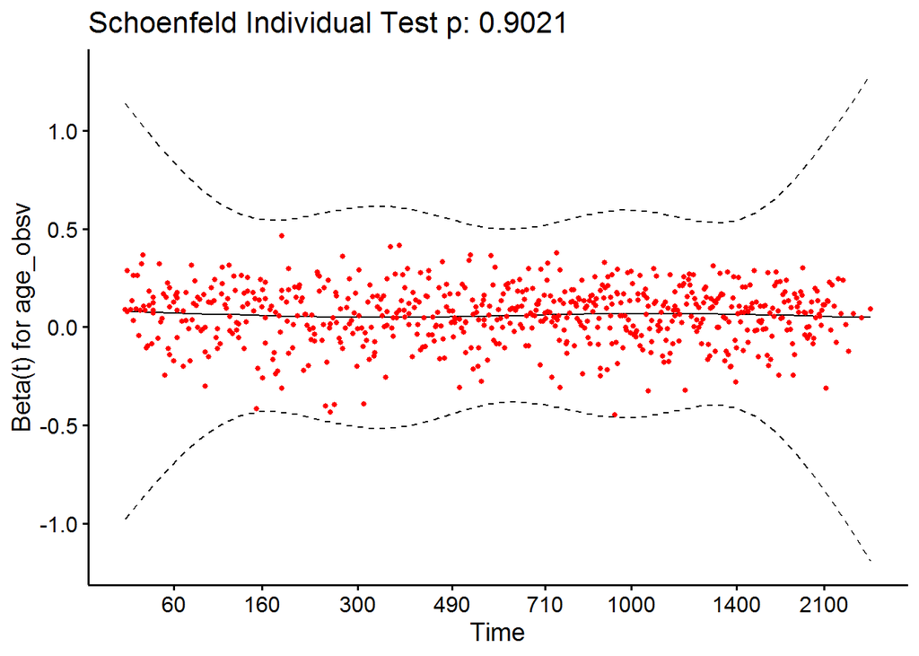

```r
ggcoxzph(resm16a)[2]
```

```
## $`2`
```

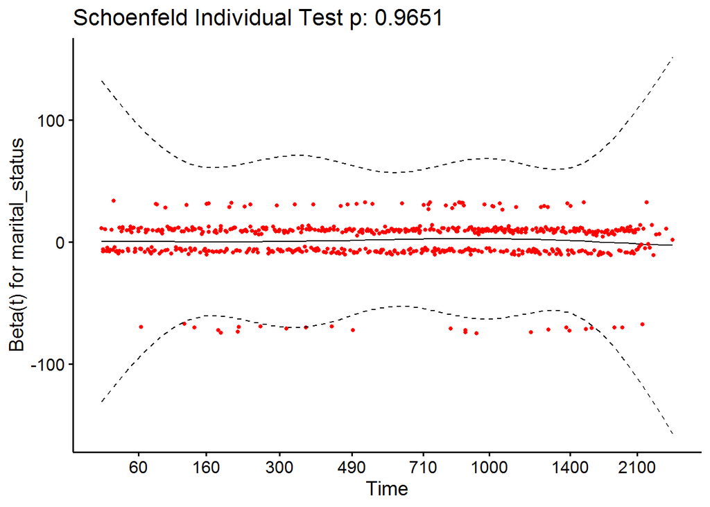

```r
ggcoxzph(resm16a)[3]
```

```
## $`3`
```

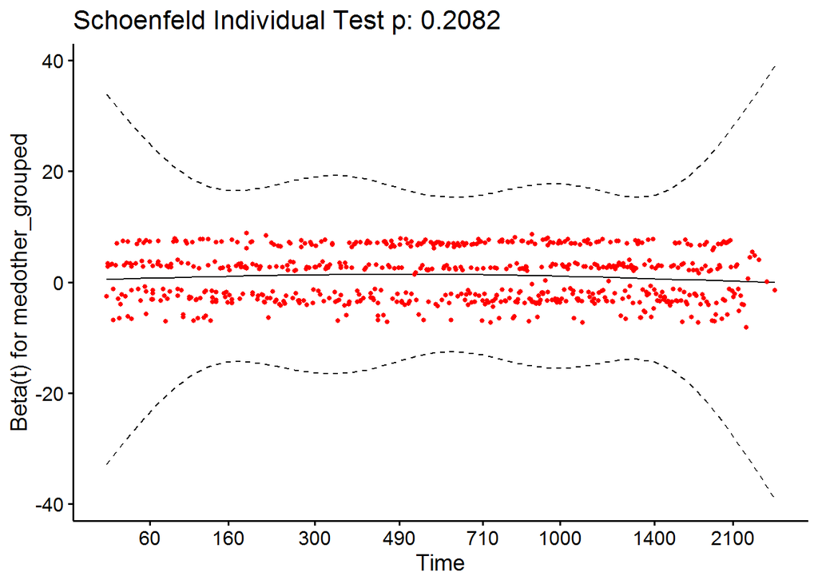

```r
anova(cox_m16a)
```

```
## Analysis of Deviance Table
##  Cox model: response is Surv(time1, time2, event_death)
## Terms added sequentially (first to last)
##
##                   loglik   Chisq Df Pr(>|Chi|)
## NULL             -3709.1
## age_obsv         -3641.3 135.573  1  < 2.2e-16 ***
## marital_status   -3639.8   2.967  3     0.3967
## medother_grouped -3624.2  31.274  6  2.247e-05 ***
## ---
## Signif. codes:  0 '***' 0.001 '**' 0.01 '*' 0.05 '.' 0.1 ' ' 1
```

We removed marital status because it was not a significant covariate in model

**Age at observation and chronic medication**

```r
cox_m16b <- coxph(Surv(time1, time2, event_death) ~ age_obsv + medother_grouped, data = all_df)

summary(cox_m16b)
```

```
## Call:
## coxph(formula = Surv(time1, time2, event_death) ~ age_obsv +
##     medother_grouped, data = all_df)
##
##   n= 17400, number of events= 1150
##    (41573 observations deleted due to missingness)
##
##                                coef exp(coef)  se(coef)      z Pr(>|z|)
## age_obsv                   0.063954  1.066043  0.004256 15.027  < 2e-16 ***
## medother_groupedInsulin   -0.263029  0.768720  0.167625 -1.569 0.116612
## medother_groupedSNRIs     -0.445540  0.640478  0.207576 -2.146 0.031842 *
## medother_groupedSSRIs     -0.325268  0.722334  0.078233 -4.158 3.22e-05 ***
## medother_groupedTCAs      -0.614696  0.540806  0.185431 -3.315 0.000917 ***
## medother_groupedTeCAs     -0.336123  0.714535  0.100591 -3.341 0.000833 ***
## medother_groupedTrazodone  0.080521  1.083851  0.083538  0.964 0.335108
## ---
## Signif. codes:  0 '***' 0.001 '**' 0.01 '*' 0.05 '.' 0.1 ' ' 1
##
##                           exp(coef) exp(-coef) lower .95 upper .95
## age_obsv                     1.0660     0.9380    1.0572    1.0750
## medother_groupedInsulin      0.7687     1.3009    0.5535    1.0677
## medother_groupedSNRIs        0.6405     1.5613    0.4264    0.9620
## medother_groupedSSRIs        0.7223     1.3844    0.6196    0.8420
## medother_groupedTCAs         0.5408     1.8491    0.3760    0.7778
## medother_groupedTeCAs        0.7145     1.3995    0.5867    0.8703
## medother_groupedTrazodone    1.0839     0.9226    0.9202    1.2767
##
## Concordance= 0.651  (se = 0.01 )
## Likelihood ratio test= 292.3  on 7 df,   p=<2e-16
## Wald test            = 281.9  on 7 df,   p=<2e-16
## Score (logrank) test = 285.7  on 7 df,   p=<2e-16
```

```r
cox.zph(cox_m16b)
```

```
##                  chisq df    p
## age_obsv         0.121  1 0.73
## medother_grouped 8.645  6 0.19
## GLOBAL           9.009  7 0.25
```

```r
resm16b <- cox.zph(cox_m16b)

ggcoxzph(resm16b)[1]
```

```
## $`1`
```

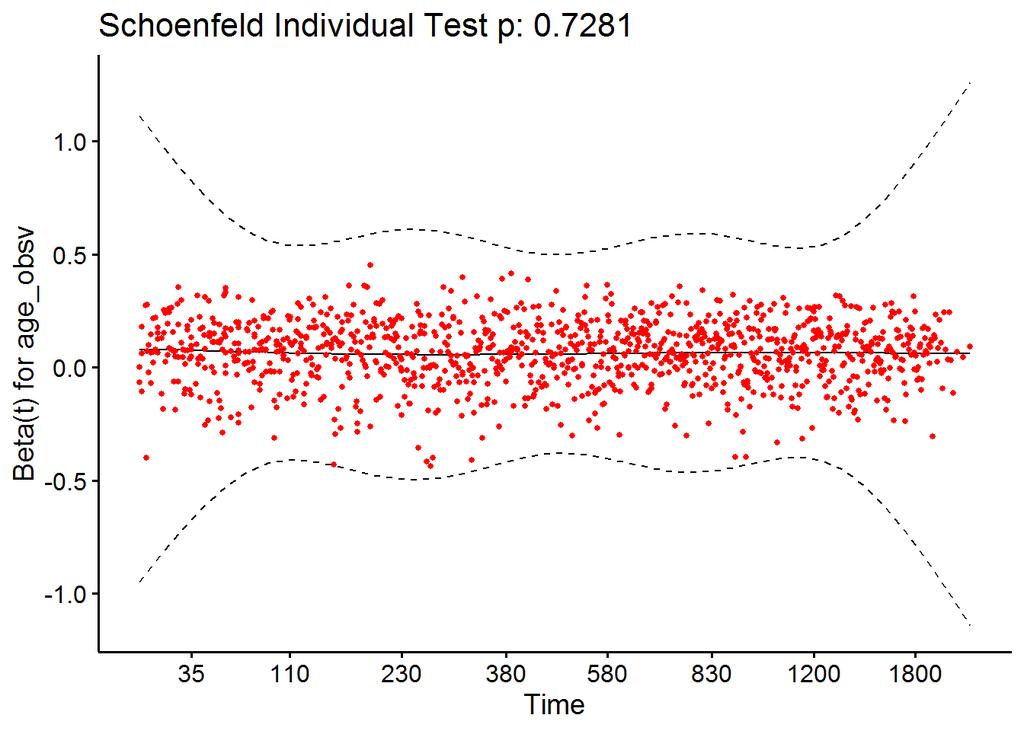

```r
ggcoxzph(resm16b)[2]
```

```
## $`2`
```

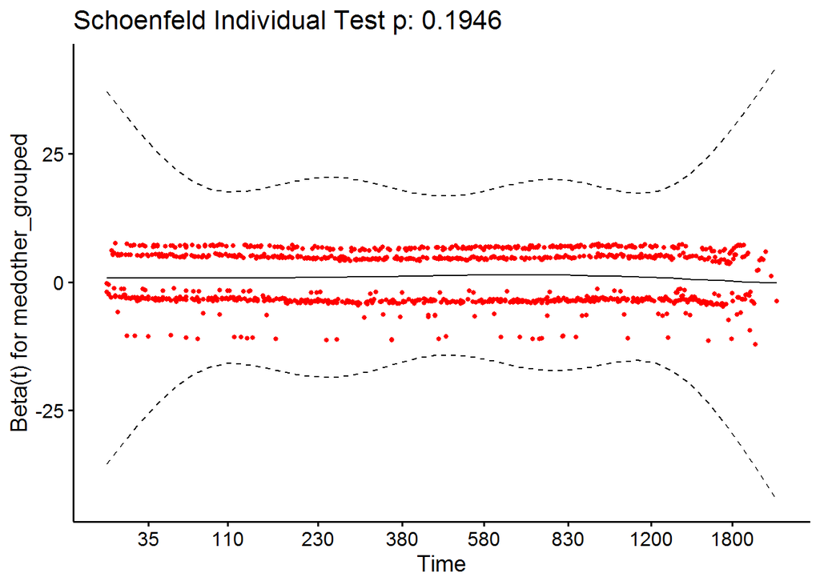

```r
anova(cox_m16b)
```

```
## Analysis of Deviance Table
##  Cox model: response is Surv(time1, time2, event_death)
## Terms added sequentially (first to last)
##
##                   loglik   Chisq Df Pr(>|Chi|)
## NULL             -7099.9
## age_obsv         -6976.6 246.588  1  < 2.2e-16 ***
## medother_grouped -6953.8  45.686  6  3.418e-08 ***
## ---
## Signif. codes:  0 '***' 0.001 '**' 0.01 '*' 0.05 '.' 0.1 ' ' 1
```

*Forest plot*

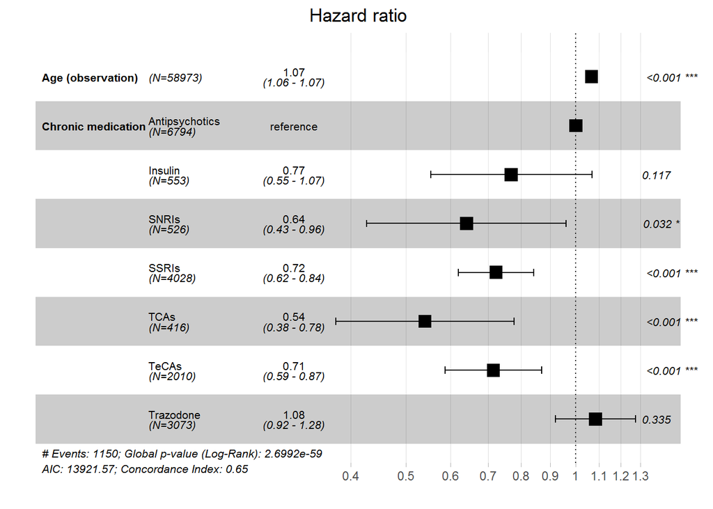

```r
forest_df16b <- all_df %>%
  transmute(time1,
            time2,
            event_death,
            `Age (observation)` = age_obsv,
            `Chronic medication` = medother_grouped)

new16b <- coxph(Surv(time1, time2, event_death) ~  `Age (observation)` + `Chronic medication`, data = forest_df16b)

ggforest(new16b,
         cpositions = c(0.01, 0.175, 0.4))
```

**Gender, age at observation, cognitive assessment score, and chronic medication**

```r
cox_m17 <- coxph(Surv(time1, time2, event_death) ~  Gender_Value + age_obsv + numerator + medother_grouped, data = all_df)

summary(cox_m17)
```

```
## Call:
## coxph(formula = Surv(time1, time2, event_death) ~ Gender_Value +
##     age_obsv + numerator + medother_grouped, data = all_df)
##
##   n= 4406, number of events= 265
##    (54567 observations deleted due to missingness)
##
##                                coef exp(coef)  se(coef)      z Pr(>|z|)
## Gender_ValueMale           0.115625  1.122575  0.131497  0.879   0.3792
## age_obsv                   0.090025  1.094202  0.009466  9.510  < 2e-16 ***
## numerator                 -0.068850  0.933467  0.009136 -7.536 4.85e-14 ***
## medother_groupedInsulin    0.137760  1.147700  0.284518  0.484   0.6283
## medother_groupedSNRIs      0.154088  1.166594  0.372263  0.414   0.6789
## medother_groupedSSRIs     -0.370087  0.690675  0.183410 -2.018   0.0436 *
## medother_groupedTCAs      -0.683212  0.504992  0.296101 -2.307   0.0210 *
## medother_groupedTeCAs     -0.476991  0.620648  0.231930 -2.057   0.0397 *
## medother_groupedTrazodone -0.036697  0.963968  0.220028 -0.167   0.8675
## ---
## Signif. codes:  0 '***' 0.001 '**' 0.01 '*' 0.05 '.' 0.1 ' ' 1
##
##                           exp(coef) exp(-coef) lower .95 upper .95
## Gender_ValueMale             1.1226     0.8908    0.8675    1.4526
## age_obsv                     1.0942     0.9139    1.0741    1.1147
## numerator                    0.9335     1.0713    0.9169    0.9503
## medother_groupedInsulin      1.1477     0.8713    0.6571    2.0045
## medother_groupedSNRIs        1.1666     0.8572    0.5624    2.4199
## medother_groupedSSRIs        0.6907     1.4479    0.4821    0.9894
## medother_groupedTCAs         0.5050     1.9802    0.2826    0.9022
## medother_groupedTeCAs        0.6206     1.6112    0.3939    0.9778
## medother_groupedTrazodone    0.9640     1.0374    0.6263    1.4837
##
## Concordance= 0.732  (se = 0.019 )
## Likelihood ratio test= 170.4  on 9 df,   p=<2e-16
## Wald test            = 160.6  on 9 df,   p=<2e-16
## Score (logrank) test = 164.4  on 9 df,   p=<2e-16
```

```r
cox.zph(cox_m17)
```

```
##                   chisq df    p
## Gender_Value     0.5095  1 0.48
## age_obsv         0.0693  1 0.79
## numerator        0.7070  1 0.40
## medother_grouped 3.9120  6 0.69
## GLOBAL           5.1124  9 0.82
```

```r
resm17 <- cox.zph(cox_m17)

ggcoxzph(resm17)[1]
```

```
## $`1`
```

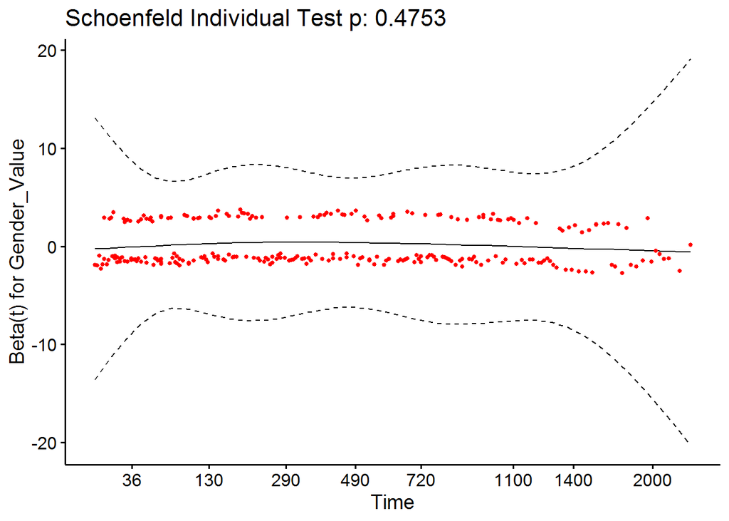

```r
ggcoxzph(resm17)[2]
```

```
## $`2`
```

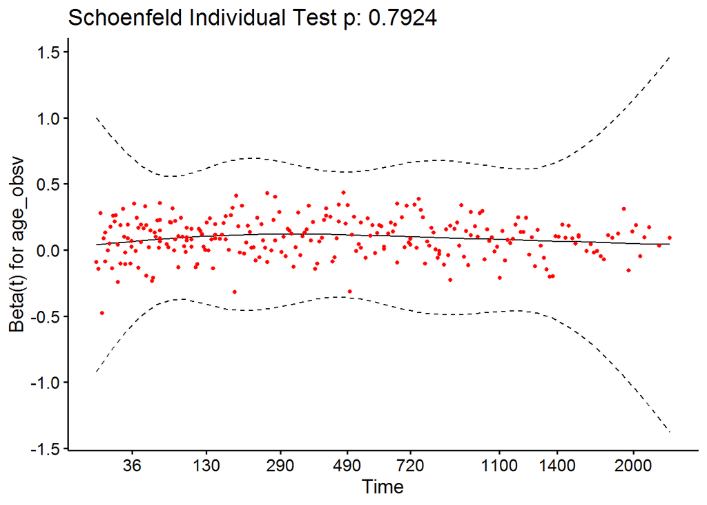

```r
ggcoxzph(resm17)[3]
```

```
## $`3`
```

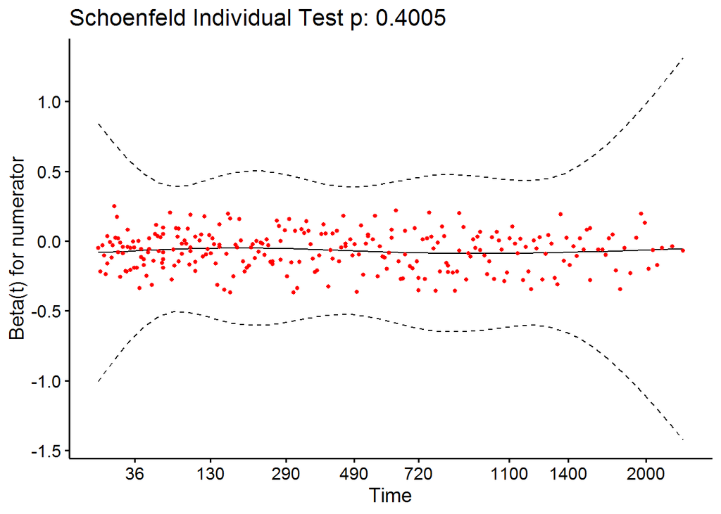

```r
ggcoxzph(resm17)[4]
```

```
## $`4`
```

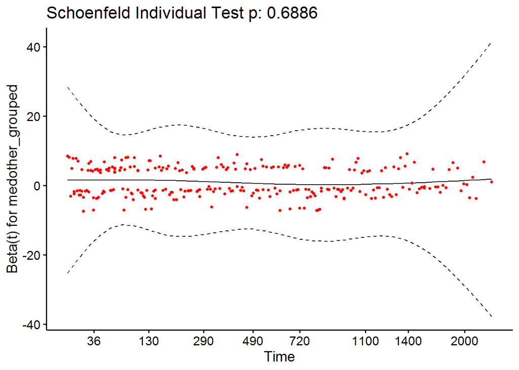

```r
anova(cox_m17)
```

```
## Analysis of Deviance Table
##  Cox model: response is Surv(time1, time2, event_death)
## Terms added sequentially (first to last)
##
##                   loglik    Chisq Df Pr(>|Chi|)
## NULL             -1335.0
## Gender_Value     -1335.0   0.0079  1    0.92922
## age_obsv         -1284.6 100.7122  1  < 2.2e-16 ***
## numerator        -1257.0  55.3432  1  1.012e-13 ***
## medother_grouped -1249.8  14.3605  6    0.02586 *
## ---
## Signif. codes:  0 '***' 0.001 '**' 0.01 '*' 0.05 '.' 0.1 ' ' 1
```

We removed gender:

**Age at observation, cognitive assessment score, and chronic medication**

```r
cox_m17a <- coxph(Surv(time1, time2, event_death) ~ age_obsv + numerator + medother_grouped, data = all_df)

summary(cox_m17a)
```

```
## Call:
## coxph(formula = Surv(time1, time2, event_death) ~ age_obsv +
##     numerator + medother_grouped, data = all_df)
##
##   n= 4406, number of events= 265
##    (54567 observations deleted due to missingness)
##
##                                coef exp(coef)  se(coef)      z Pr(>|z|)
## age_obsv                   0.089371  1.093486  0.009453  9.454  < 2e-16 ***
## numerator                 -0.068884  0.933435  0.009153 -7.526 5.23e-14 ***
## medother_groupedInsulin    0.154748  1.167364  0.283901  0.545   0.5857
## medother_groupedSNRIs      0.168467  1.183489  0.371946  0.453   0.6506
## medother_groupedSSRIs     -0.366380  0.693239  0.183300 -1.999   0.0456 *
## medother_groupedTCAs      -0.705854  0.493687  0.294912 -2.393   0.0167 *
## medother_groupedTeCAs     -0.473188  0.623013  0.231916 -2.040   0.0413 *
## medother_groupedTrazodone -0.030354  0.970102  0.220009 -0.138   0.8903
## ---
## Signif. codes:  0 '***' 0.001 '**' 0.01 '*' 0.05 '.' 0.1 ' ' 1
##
##                           exp(coef) exp(-coef) lower .95 upper .95
## age_obsv                     1.0935     0.9145    1.0734    1.1139
## numerator                    0.9334     1.0713    0.9168    0.9503
## medother_groupedInsulin      1.1674     0.8566    0.6692    2.0364
## medother_groupedSNRIs        1.1835     0.8450    0.5709    2.4534
## medother_groupedSSRIs        0.6932     1.4425    0.4840    0.9929
## medother_groupedTCAs         0.4937     2.0256    0.2770    0.8800
## medother_groupedTeCAs        0.6230     1.6051    0.3954    0.9815
## medother_groupedTrazodone    0.9701     1.0308    0.6303    1.4931
##
## Concordance= 0.732  (se = 0.019 )
## Likelihood ratio test= 169.7  on 8 df,   p=<2e-16
## Wald test            = 158.9  on 8 df,   p=<2e-16
## Score (logrank) test = 162.8  on 8 df,   p=<2e-16
```

```r
cox.zph(cox_m17a)
```

```
##                   chisq df    p
## age_obsv         0.0606  1 0.81
## numerator        0.7566  1 0.38
## medother_grouped 4.0121  6 0.68
## GLOBAL           4.5857  8 0.80
```

```r
resm17a <- cox.zph(cox_m17a)

ggcoxzph(resm17a)[1]
```

```
## $`1`
```

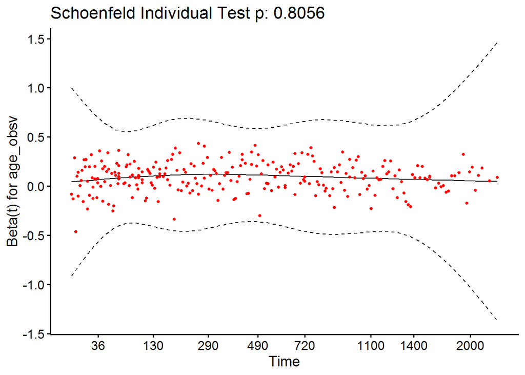

```r
ggcoxzph(resm17a)[2]
```

```
## $`2`
```

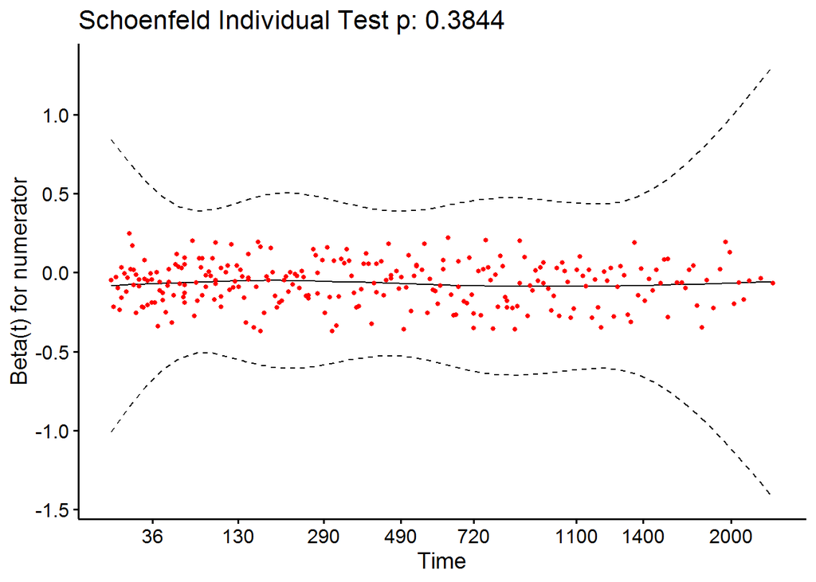

```r
ggcoxzph(resm17a)[3]
```

```
## $`3`
```

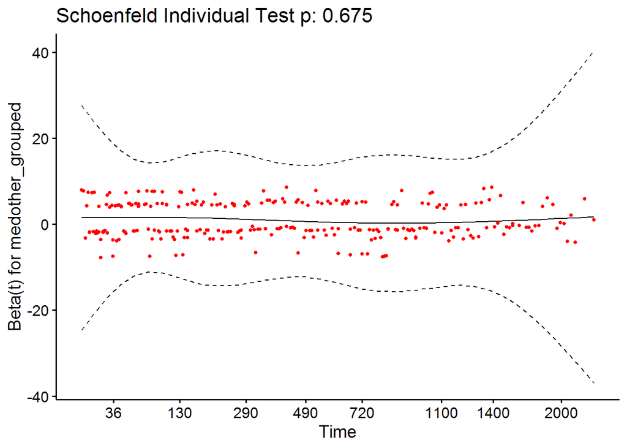

```r
anova(cox_m17a)
```

```
## Analysis of Deviance Table
##  Cox model: response is Surv(time1, time2, event_death)
## Terms added sequentially (first to last)
##
##                   loglik  Chisq Df Pr(>|Chi|)
## NULL             -1335.0
## age_obsv         -1285.5 99.074  1  < 2.2e-16 ***
## numerator        -1257.7 55.462  1  9.527e-14 ***
## medother_grouped -1250.2 15.123  6    0.01933 *
## ---
## Signif. codes:  0 '***' 0.001 '**' 0.01 '*' 0.05 '.' 0.1 ' ' 1
```

*Forest plot*

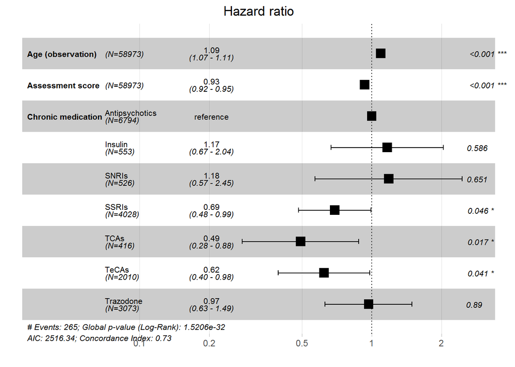

```r
forest_df17a <- all_df %>%
  transmute(time1,
            time2,
            event_death,
            `Age (observation)` = age_obsv,
            `Assessment score` = numerator,
            `Chronic medication` = medother_grouped)

new17a <- coxph(Surv(time1, time2, event_death) ~  `Age (observation)` + `Assessment score` + `Chronic medication`, data = forest_df17a)

ggforest(new17a,
         cpositions = c(0.01, 0.175, 0.4))
```

**Gender, age at observation, marital status, cognitive assessment score, and chronic medication**

```r
cox_m18 <- coxph(Surv(time1, time2, event_death) ~  Gender_Value + age_obsv + marital_status + numerator + medother_grouped, data = all_df)

summary(cox_m18)
```

```
## Call:
## coxph(formula = Surv(time1, time2, event_death) ~ Gender_Value +
##     age_obsv + marital_status + numerator + medother_grouped,
##     data = all_df)
##
##   n= 2725, number of events= 137
##    (56248 observations deleted due to missingness)
##
##                                       coef exp(coef)  se(coef)      z Pr(>|z|)
## Gender_ValueMale                 -0.143151  0.866623  0.201683 -0.710    0.478
## age_obsv                          0.085586  1.089356  0.014922  5.735 9.72e-09
## marital_statusDivorced/Separated -0.467547  0.626537  0.607300 -0.770    0.441
## marital_statusSingle             -0.003991  0.996017  0.445281 -0.009    0.993
## marital_statusWidowed             0.142403  1.153041  0.212791  0.669    0.503
## numerator                        -0.081775  0.921479  0.012943 -6.318 2.65e-10
## medother_groupedInsulin           0.346902  1.414678  0.450155  0.771    0.441
## medother_groupedSNRIs             0.291177  1.338001  0.568323  0.512    0.608
## medother_groupedSSRIs            -0.199315  0.819291  0.267460 -0.745    0.456
## medother_groupedTCAs             -0.424820  0.653888  0.377925 -1.124    0.261
## medother_groupedTeCAs            -0.475618  0.621501  0.333603 -1.426    0.154
## medother_groupedTrazodone         0.106900  1.112823  0.319248  0.335    0.738
##
## Gender_ValueMale
## age_obsv                         ***
## marital_statusDivorced/Separated
## marital_statusSingle
## marital_statusWidowed
## numerator                        ***
## medother_groupedInsulin
## medother_groupedSNRIs
## medother_groupedSSRIs
## medother_groupedTCAs
## medother_groupedTeCAs
## medother_groupedTrazodone
## ---
## Signif. codes:  0 '***' 0.001 '**' 0.01 '*' 0.05 '.' 0.1 ' ' 1
##
##                                  exp(coef) exp(-coef) lower .95 upper .95
## Gender_ValueMale                    0.8666     1.1539    0.5837    1.2868
## age_obsv                            1.0894     0.9180    1.0580    1.1217
## marital_statusDivorced/Separated    0.6265     1.5961    0.1906    2.0601
## marital_statusSingle                0.9960     1.0040    0.4161    2.3839
## marital_statusWidowed               1.1530     0.8673    0.7598    1.7497
## numerator                           0.9215     1.0852    0.8984    0.9452
## medother_groupedInsulin             1.4147     0.7069    0.5854    3.4185
## medother_groupedSNRIs               1.3380     0.7474    0.4392    4.0758
## medother_groupedSSRIs               0.8193     1.2206    0.4850    1.3839
## medother_groupedTCAs                0.6539     1.5293    0.3118    1.3715
## medother_groupedTeCAs               0.6215     1.6090    0.3232    1.1951
## medother_groupedTrazodone           1.1128     0.8986    0.5952    2.0805
##
## Concordance= 0.761  (se = 0.023 )
## Likelihood ratio test= 102.8  on 12 df,   p=<2e-16
## Wald test            = 94.13  on 12 df,   p=8e-15
## Score (logrank) test = 99.65  on 12 df,   p=7e-16
```

```r
cox.zph(cox_m18)
```

```
##                   chisq df     p
## Gender_Value      2.957  1 0.086
## age_obsv          1.738  1 0.187
## marital_status    0.731  3 0.866
## numerator         0.285  1 0.593
## medother_grouped  5.662  6 0.462
## GLOBAL           13.245 12 0.351
```

```r
resm18 <- cox.zph(cox_m18)

ggcoxzph(resm18)[1]
```

```
## $`1`
```

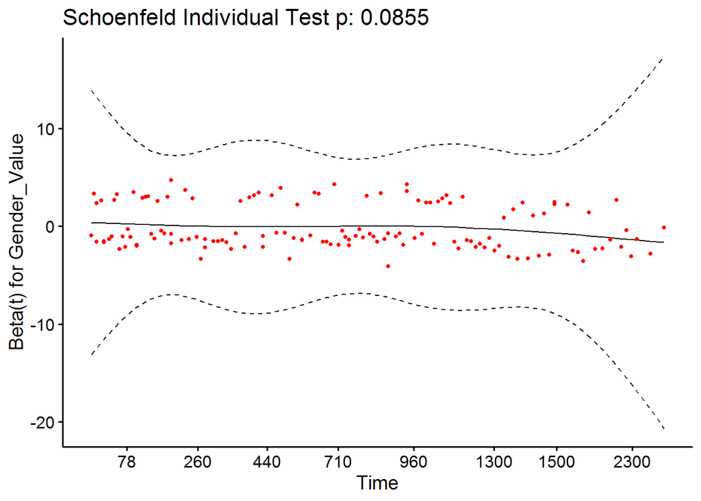

```r
ggcoxzph(resm18)[2]
```

```
## $`2`
```

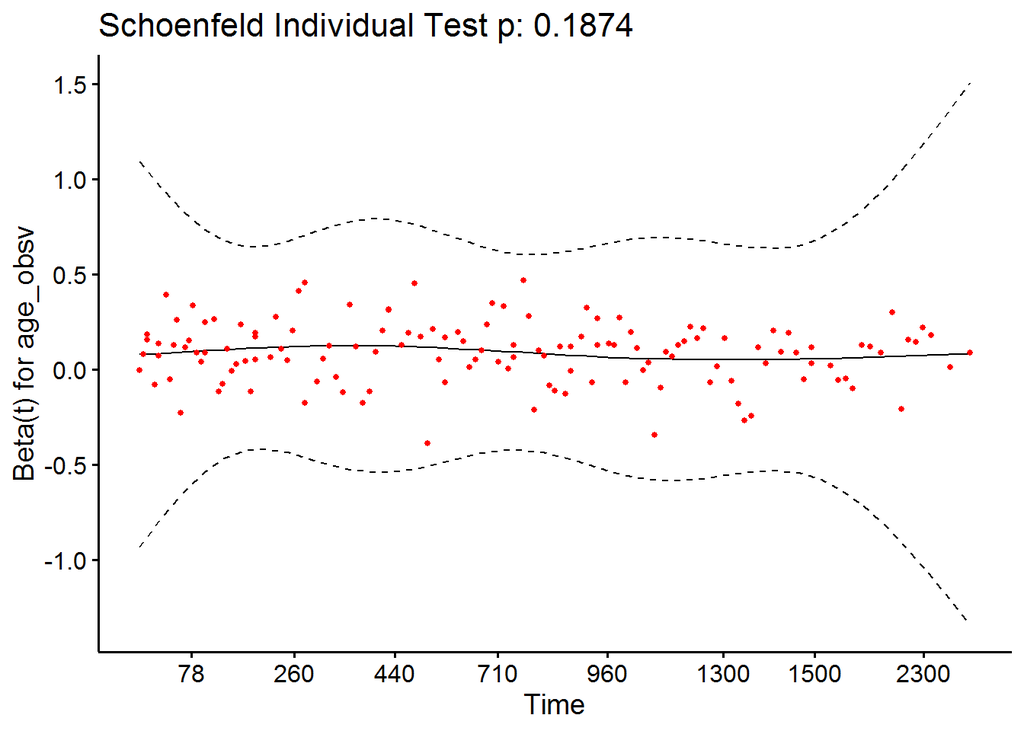

```r
ggcoxzph(resm18)[3]
```

```
## $`3`
```

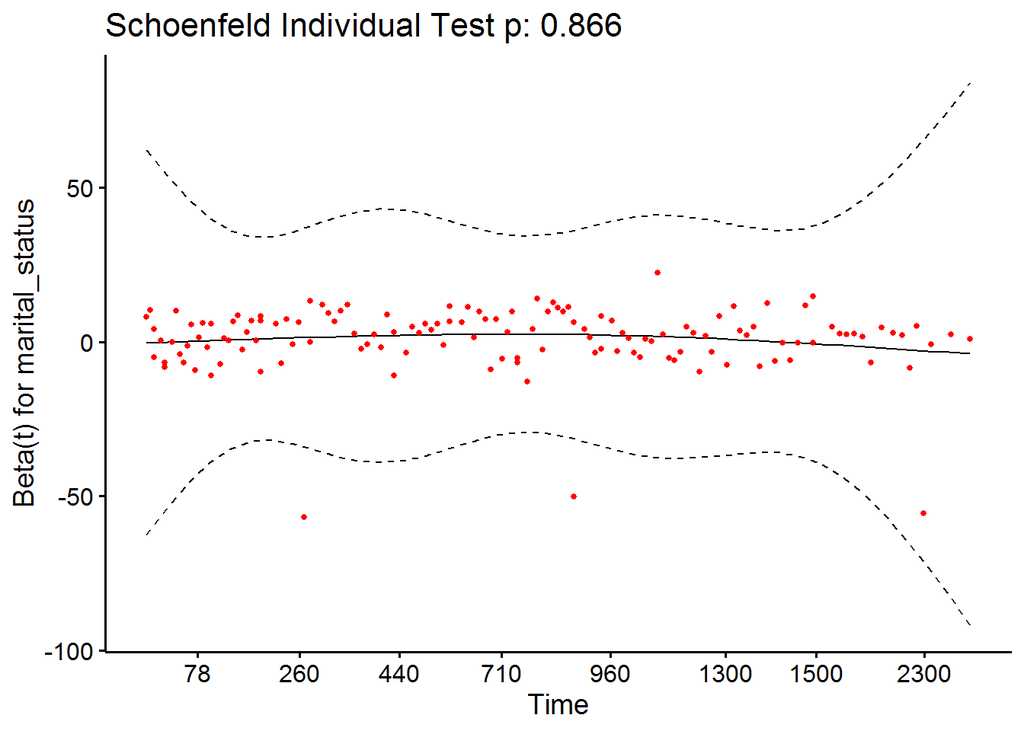

```r
ggcoxzph(resm18)[4]
```

```
## $`4`
```

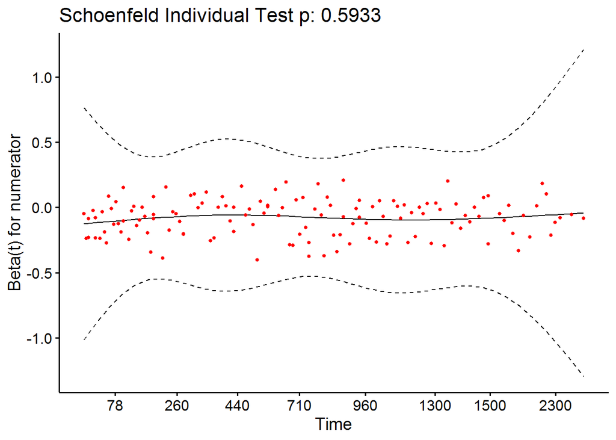

```r
ggcoxzph(resm18)[5]
```

```
## $`5`
```

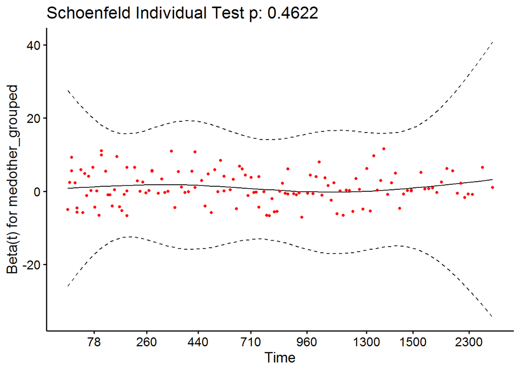

```r
anova(cox_m18)
```

```
## Analysis of Deviance Table
##  Cox model: response is Surv(time1, time2, event_death)
## Terms added sequentially (first to last)
##
##                   loglik   Chisq Df Pr(>|Chi|)
## NULL             -588.49
## Gender_Value     -587.25  2.4835  1     0.1150
## age_obsv         -561.19 52.1237  1  5.211e-13 ***
## marital_status   -560.37  1.6254  3     0.6537
## numerator        -540.46 39.8214  1  2.783e-10 ***
## medother_grouped -537.11  6.7093  6     0.3486
## ---
## Signif. codes:  0 '***' 0.001 '**' 0.01 '*' 0.05 '.' 0.1 ' ' 1
```

We removed gender:

**Age at observation, marital status, cognitive assessment score, and chronic medication**

```r
cox_m18a <- coxph(Surv(time1, time2, event_death) ~ age_obsv + marital_status + numerator + medother_grouped, data = all_df)

summary(cox_m18a)
```

```
## Call:
## coxph(formula = Surv(time1, time2, event_death) ~ age_obsv +
##     marital_status + numerator + medother_grouped, data = all_df)
##
##   n= 2725, number of events= 137
##    (56248 observations deleted due to missingness)
##
##                                      coef exp(coef) se(coef)      z Pr(>|z|)
## age_obsv                          0.08622   1.09005  0.01493  5.774 7.75e-09
## marital_statusDivorced/Separated -0.43547   0.64696  0.60587 -0.719    0.472
## marital_statusSingle              0.01203   1.01210  0.44382  0.027    0.978
## marital_statusWidowed             0.18522   1.20349  0.20418  0.907    0.364
## numerator                        -0.08148   0.92175  0.01295 -6.294 3.10e-10
## medother_groupedInsulin           0.33893   1.40344  0.44961  0.754    0.451
## medother_groupedSNRIs             0.25716   1.29325  0.56558  0.455    0.649
## medother_groupedSSRIs            -0.19719   0.82104  0.26757 -0.737    0.461
## medother_groupedTCAs             -0.38905   0.67770  0.37478 -1.038    0.299
## medother_groupedTeCAs            -0.47481   0.62200  0.33346 -1.424    0.154
## medother_groupedTrazodone         0.09929   1.10438  0.31918  0.311    0.756
##
## age_obsv                         ***
## marital_statusDivorced/Separated
## marital_statusSingle
## marital_statusWidowed
## numerator                        ***
## medother_groupedInsulin
## medother_groupedSNRIs
## medother_groupedSSRIs
## medother_groupedTCAs
## medother_groupedTeCAs
## medother_groupedTrazodone
## ---
## Signif. codes:  0 '***' 0.001 '**' 0.01 '*' 0.05 '.' 0.1 ' ' 1
##
##                                  exp(coef) exp(-coef) lower .95 upper .95
## age_obsv                            1.0900     0.9174    1.0586    1.1224
## marital_statusDivorced/Separated    0.6470     1.5457    0.1973    2.1212
## marital_statusSingle                1.0121     0.9880    0.4241    2.4155
## marital_statusWidowed               1.2035     0.8309    0.8066    1.7957
## numerator                           0.9218     1.0849    0.8987    0.9454
## medother_groupedInsulin             1.4034     0.7125    0.5814    3.3877
## medother_groupedSNRIs               1.2932     0.7732    0.4268    3.9183
## medother_groupedSSRIs               0.8210     1.2180    0.4860    1.3871
## medother_groupedTCAs                0.6777     1.4756    0.3251    1.4127
## medother_groupedTeCAs               0.6220     1.6077    0.3236    1.1957
## medother_groupedTrazodone           1.1044     0.9055    0.5908    2.0645
##
## Concordance= 0.762  (se = 0.023 )
## Likelihood ratio test= 102.3  on 11 df,   p=<2e-16
## Wald test            = 93.41  on 11 df,   p=4e-15
## Score (logrank) test = 99.19  on 11 df,   p=3e-16
```

```r
cox.zph(cox_m18a)
```

```
##                  chisq df    p
## age_obsv         1.907  1 0.17
## marital_status   0.828  3 0.84
## numerator        0.355  1 0.55
## medother_grouped 5.537  6 0.48
## GLOBAL           8.312 11 0.69
```

```r
resm18a <- cox.zph(cox_m18a)

ggcoxzph(resm18a)[1]
```

```
## $`1`
```

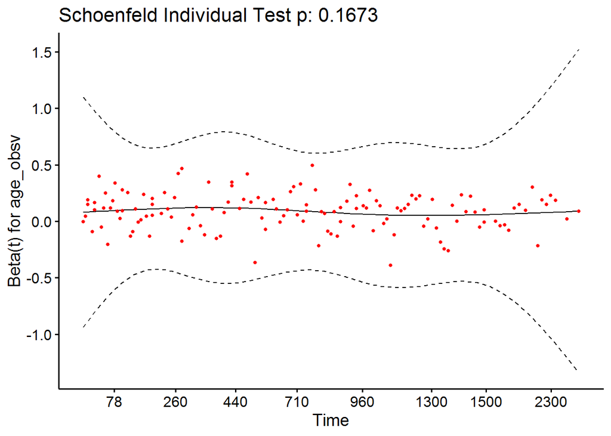